# The Analytic Layer for the MD/Harm Pathway: Verification and Prediction

Certified Identities, the Approximation Ladder, and Semi-Analytic Operating Characteristics (Continuous Outcomes)

Author

Larry F. León

Published

August 27, 2026

# 1 Scope and provenance

This document consolidates the analytic materials for the continuous/MD harm pathway into a single reference. It combines, and is intended to supersede as the working reference, two committed documents in this directory: `analytic_verification_math_details.qmd` (the verification tiers: what closed forms certify exactly) and `analytic_derivations_mr_operating_characteristics.qmd` (the prediction layer: which multiplier-resampling (MR) operating characteristics are derivable before a grid runs). Both parents are retained in the repository, marked superseded and frozen: their executable chunks are disabled so that no superseded prediction can be regenerated from them. Beyond consolidation, this document adds two things: the connective material between verification and prediction — the explicit ladder from exact identities to each approximation actually carried out, including the population-level covariance decomposition previously deferred and now derived and verified — and a detailed worked example (Section 6) that carries the machinery end to end against a specific committed simulation design, stating for every predicted quantity what is computed, from which inputs, and which column of the design’s own report it should be compared against.

Supporting artifacts: `dev/detection-theory-continuous/` (`NOTE_declaration_gaussian_md.md`; `check_declaration_gaussian_md.R`, on-record 16 PASS / 0 FAIL, cross-stack identical output on R 4.6.1/mvtnorm 1.4.2 and R 4.3.3/mvtnorm 1.2.4; and `check_additive_covariance_md.R`, the additive-decomposition verification cited in Section 4).

Estimand language is strict throughout. $\beta(\hat H)$ is the conditional estimand — the exact treatment effect at the realized, data-selected rule, computed on the fixed super-population with zero Monte Carlo error. $\theta^\dagger(H)$ is the marginal true-subgroup effect at the designed region $Q$. MR conditions on the realized candidate family, targets $\beta(\hat H)$, and is scored against $\beta(\hat H)$, never $\theta^\dagger$. Effects are reported on the oriented scale, on which positive is the signal the procedure searches for; exact references are stored on the raw scale and the orientation bridge applies the sign map once. What that orientation means for this fixture is spelled out in §2 — it encodes a treatment switch, not a claim that larger CD4 change is worse.

# 2 Fixture, estimator, and event conventions

**The generative model, from first principles.** Everything random in this document is generated by the following process, and every expectation and variance below is an integral over its joint law — no other randomness exists anywhere.

1. *Cohort and its surfaces (fixed).* `df_super` is a fixed table of $N = 5000$ rows; row $i$ carries a covariate vector $x_i$. Attached to the cohort are two deterministic real-valued functions of the covariates, fixed once and for all: the **control-arm mean surface** $\mu_0(\cdot)$, the expected outcome of a subject with covariates $x$ if left untreated, and the **treatment-effect surface** $\tau(\cdot)$, the amount by which treatment shifts that expectation at $x$. Writing $\mu_1 := \mu_0 + \tau$ for the treated-arm mean surface, the pair $\mu_0, \mu_1$ are the *arm mean surfaces* and
   $$\tau(x) \;=\; \mu_1(x) - \mu_0(x)$$
   is the **conditional average treatment effect (CATE)** — the treatment effect at a *given covariate value*, as opposed to one averaged over a population or a region. Step 4 below makes the correspondence to potential outcomes exact, $\mu_w(x) = \mathbb E[Y(w) \mid X = x]$ for $w \in \{0,1\}$. Nothing in the cohort is random: $\mu_0$, $\tau$ and the rows themselves are fixed.
2. *Trial draw.* The trial subjects’ covariates $X_1, \dots, X_n$ are i.i.d. draws from the **empirical distribution of the cohort**, defined on rows rather than values: row indices $I_1, \dots, I_n$ are i.i.d. uniform on $\{1, \dots, N\}$ and $X_k := x_{I_k}$, so that if distinct rows share a covariate value, $X_k$ takes that value with the corresponding multiplicity — the draw is of a row, never of a value. Membership statements such as $X_k \in g$ mean the drawn row lies in $g$. This i.i.d. superpopulation model is the analytic model behind every formula in this document; with $n \ll N$ it is the standard idealization of sampling the cohort.
3. *Assignment.* $W_1, \dots, W_n$ are i.i.d. $\mathrm{Bernoulli}(1/2)$, independent of $(X_1, \dots, X_n)$.
4. *Noise and outcomes.* $\varepsilon_1, \dots, \varepsilon_n$ are i.i.d. $N(0, \sigma^2)$, independent of the $X$’s and $W$’s, and
   $$Y_k \;=\; \mu_0(X_k) + W_k\,\tau(X_k) + \varepsilon_k,
   \qquad\text{i.e.}\qquad
   Y_k(w) = \mu_0(X_k) + w\,\tau(X_k) + \varepsilon_k,$$
   one shared noise draw per subject across the two potential outcomes.

**Index convention.** Two index letters run throughout and are never interchanged: $i$ ranges over the $N$ **cohort rows** (so $x_i$, $\mu_0(x_i)$, and every sum $\sum_{i \in g}$ in a region moment are cohort-level and fixed), while $k$ ranges over the $n$ **trial subjects** (so $X_k, W_k, \varepsilon_k, Y_k$ are random). Part II’s Level 2 and Appendix B index trial subjects by $i$ instead, following the source notation of [W]; that local convention is flagged where it occurs and changes nothing.

The triples $(X_k, W_k, \varepsilon_k)$, $k = 1, \dots, n$, are the **complete list of random quantities**; a *statistic* is any measurable function of them, and $\mathbb E[\cdot]$, $\operatorname{Var}[\cdot]$, $\sigma[\cdot] = \sqrt{\operatorname{Var}[\cdot]}$ without further qualification always integrate over their joint law.

The fixture instantiating that model — the committed harm-pathway cohort `df_super` above (`actg175_continuous_simulations.qmd` lines 65, 100, 118–119) — fixes the following. The designed harm region is the covariate rule $Q = \{\text{age} > 34 \ \wedge\ \text{preanti} \le 744.5\}$, with $|Q| = 1723$ members and prevalence $\pi = P(Q) = |Q|/N = 0.3446$. Raw-scale (stored) effects: $\tau_Q = -40$ (calibration target), $\tau_{Q^c} = -26.255$, $\beta_{\mathrm{int}} = \tau_Q - \tau_{Q^c} = -13.745$. The CATE is two-valued. Screening floor $c_1 = 30$ and consistency floor $c_2 = 10$, both on the oriented scale fixed later in this section, once the region effect $\beta(g)$ has been defined. The outcome is CD4 change from baseline to week 20 (`cd420 - cd40`) in ACTG175 arms 1 and 3.

Two data-generating-mechanism (DGM) ingredients enter every variance formula below and are **not** free constants: the noise scale $\sigma$ and the control-arm mean surface $\mu_0$. Both are fitted from the trial rather than specified — `generate_glm_dgm()` builds the super-population from a Gaussian GLM on the discretised `z1`–`z12` factor formulation, and the residual standard deviation of that baseline fit is preserved as $\sigma$ (`actg175_continuous_simulations.qmd`, Design Notes item 3), with $\mu_0$ the fitted control surface. They are therefore enumerable on `df_super` even though they have no closed form in terms of the design parameters, which is what makes the Level 4 diagonal of Section 4.4 computable in principle and the measured scale **anchor** — defined with the scale notation below — necessary in practice.

The anchor and its cross-check are stated at the end of this section, after the notation they use is defined.

**Notation used throughout.** A *region* (equivalently a *rule*) $H$ or $g$ is a subset of the covariate space — in practice a conjunction of covariate conditions — identified with the subset of `df_super` rows it selects; $\hat H$ is the data-selected region. Its *prevalence* is $P(g) = |g|/N$, and its **purity** is
$$P(Q \mid g) \;=\; \frac{|g \cap Q|}{|g|},$$
the fraction of $g$’s members lying inside the designed region $Q$ — so $P(Q \mid Q) = 1$, and $P(Q \mid g) = \pi$ exactly when $|g \cap Q| = \pi\,|g|$ — when $g$ contains $Q$-members at the cohort’s own rate. Such a rule is called **$Q$-neutral** here: neither enriched nor depleted relative to the baseline, the whole-sample rule being the canonical case. This is an arithmetic property of two fixed subsets of `df_super` — a coincidence of counts, not a probabilistic independence statement, since nothing is random once the cohort is fixed. The natural summary is the **enrichment ratio** $P(Q \mid g)/\pi$: greater than $1$ for enriched rules, exactly $1$ for $Q$-neutral ones, less than $1$ for depleted ones. Containment is neither necessary nor sufficient for neutrality, a point made precise below.

One region is named here and used throughout: $\mathcal S$, the **everyone rule** — the region containing every subject, so $P(\mathcal S) = 1$ and $P(Q \mid \mathcal S) = \pi$. It is the canonical $Q$-neutral rule, and its effect is the intention-to-treat (ITT) contrast. $\mathcal S$ always names a *rule*, never “the sample”.

**Region moments: indexed, not conditioned.** The cohort `df_super` is fixed, and the surfaces $\mu_0, \tau$ are deterministic functions of the covariates — so no dispersion of theirs is a variance in the distributional sense, and this document does not write one. For a covariate function $a(\cdot)$ and a region $g$, define the **indexed region moments**
$$m_g[a] = \frac{1}{|g|}\sum_{i \in g} a(x_i),
\qquad
V_g[a] = \frac{1}{|g|}\sum_{i \in g}\big(a(x_i) - m_g[a]\big)^2,$$
and
$$C_g[a, b] = \frac{1}{|g|}\sum_{i \in g}
\big(a(x_i) - m_g[a]\big)\big(b(x_i) - m_g[b]\big),$$
the sums running over the fixed cohort rows $x_i$ of the region: finite-population summary functionals of the cohort, indexed by the region, computed by enumeration, carrying no sampling variability whatever. If one introduces the uniform draw $X$ from the $N$ rows — the counting measure already underlying $P(g)$ and the purity — these coincide with moments conditioned on the *event* $\{X \in g\}$: $m_g[a] = \mathbb E[a(X) \mid X \in g]$ and so on. That event-conditional reading is available but never required, and a bare conditioning bar on a region is written nowhere. The literature’s population forms are the $g = \mathcal S$ case with the random argument explicit — $\operatorname{Var}[\tau(X)]$ in [W] (eq. 3.20) and $\operatorname{Var}[\tau(X_i)]$ in [W-notes] — that is, $V_{\mathcal S}[\tau]$ here; the region-indexed forms are this document’s, because its subject is regions. In particular the **effect of a region** is the indexed mean of the CATE, $\beta(g) := m_g[\tau]$ — shown below to equal $\mathbb E[Y(1) - Y(0) \mid X \in g]$ — and the CATE’s dispersion within $g$ is $S_\tau^2(g) = V_g[\tau] = \beta_{\mathrm{int}}^2\,p(1-p)$ at $p = P(Q \mid g)$.

Genuine randomness enters in exactly two places, and only there do distributional statements appear: the outcome noise $\varepsilon$ (variance $\sigma^2$) and the treatment assignment $W$. Outcome variances therefore mix a distributional part and an indexed part, written with the event explicit, and the mix follows from the model rather than by assertion: since $Y(w) = \mu_0(X) + w\tau(X) + \varepsilon$ with $\varepsilon$ independent of $X$, conditioning on the event $\{X \in g\}$ leaves $\varepsilon$ untouched and reduces the $X$-part to the indexed moment, so $\operatorname{Var}(Y(w) \mid X \in g) = \sigma^2 + V_g[\mu_0 + w\tau]$. Estimator variances — $\operatorname{Var}[\hat\beta(g)]$, $\Sigma_{\mathrm{pop}}$, $V_{\mathrm{DM}}$ (the difference-in-means variance of Section 4.4), $V^\ast$ (the efficiency bound of Section 10.3) — are a third category again: sampling variances of statistics over $(W, \varepsilon)$ and the trial draw.

**Population versus sample, and what the super-population is for.** The counting interpretation transfers to a trial of size $n$ — conditionally on the drawn sample a rule’s members are again just rows, and the sample purity $|g \cap Q|_n / |g|_n$ is again arithmetic — but the *status* of the two quantities differs, and the document depends on the difference. On `df_super` the purity $P(Q \mid g)$ is a **fixed constant**: it is what Proposition 1 (Part I) converts into $\beta(g)$, with no sampling variability whatsoever. In a realized trial the sample purity is a **random variable**, fluctuating about the population value with standard deviation $\approx \sqrt{p(1-p)/n_g}$ at $p = P(Q \mid g)$ and $n_g = nP(g)$. So a $Q$-neutral rule is neutral *exactly* at the cohort level and *in expectation* at the sample level — the same relation the stylized independent covariate of Section 6 bears to the cohort, giving a three-level pattern in which each level’s exact condition is the next level’s expectation: DGM $\to$ cohort $\to$ sample.

Sample purity is therefore neither an estimand nor an error source here. Every mean this document computes is the population mixture value, and the sample-composition fluctuation is already carried by the covariance layers — the prognostic-imbalance component of the design-conditional mean decomposition (Section 4, Level 2) and the $u^{(g)}, t^{(g)}$ moments of the additive population covariance (Section 4.4). This is precisely the role of the super-population: it fixes the estimand side exactly — $\beta(H)$ for every rule, including every realized $\hat H$ — so that all randomness lives in the estimator and none in the target. Writing sample purity into a mean would introduce an error term the ladder of Section 4 does not carry; the exactness of CHECK A — the mixture identity certified in Proposition 1 below — depends on not doing so. The *effect* of a region,
$$\beta(g) \;=\; \mathbb E\big[\,Y(1) - Y(0) \mid X \in g\,\big]
\ \text{on the oriented scale},$$
is its average treatment effect, computed exactly on `df_super`. **All effect symbols in this document are oriented by default**: $\tau_{Q^c} = +26.255$, $\beta_{\mathrm{int}} = +13.745$, $\tau_Q = \beta(Q) = +40$.

*What the orientation encodes.* The fixture is a **benefit search conducted by treatment switching**, and the two scales differ by which arm is labelled treated. On the trial’s original coding (the combination arm ZDV+ddI as treated), $\mathrm{MD}(Q) = -40$: the combination produces $40$ cells/$\mu$L *less* CD4 improvement in $Q$ than ddI monotherapy — harm from the active combination, which is why this is the harm pathway and why the stored references are negative. The builder calibrates with the roles switched (ddI treated), on which the identical contrast reads $+40$, and that switched scale is what this document calls oriented. So “positive $=$ harm” is a statement about the searched signal, **not** a claim that a larger CD4 change is clinically worse. The effect estimator runs at the continuous-outcome default `adverse_outcome = FALSE`; the fixture separately sets `adverse_outcome = TRUE` for the standalone GRF identifier alone (`grf_adverse_outcome`, passed only to `grf.subg.harm.glm()`), because that routine maximizes $-\mathrm{CATE}$ and needs the internal negation to search in the same direction — a GRF-side convention with no bearing on the quantities computed here. Raw (stored) values appear only when quoting stored references, and the word *oriented* is never abbreviated to a super- or subscript — in this project the prefix `or_` belongs to the **oracle** estimator, and the two must not collide. Likewise the letter $g$ is reserved for regions: where a GLM link function is needed it is written $\kappa$, never $g$. Display convention: numeric constants are shown to three decimals (four where a stored anchor is itself a four-decimal quantity, e.g., $\pi = 0.3446$ and Jaccard $0.882$); stored references retain full precision, and every exactness check compares at machine precision regardless of display.

**Scale notation:** the estimator $\hat\beta_n(g)$ and the joint law over which every operator integrates are defined above; every expectation and variance names the statistic it belongs to. **The trial-size subscript is suppressed under a single ambient $n$** — $\hat\beta(g) \equiv \hat\beta_n(g)$ — and written only when a specific size is meant (the anchor at $1000$) or two sizes are related (the scaling law); the only other size in this document, the cohort’s $N = 5000$, indexes no estimator: the size-$N$ “population versions” are exactly the moments $m_g[\cdot]$, $V_g[\cdot]$, $\beta(g)$, which are constants, not statistics. So the scale of a candidate is written $\sigma[\hat\beta(g)]$ — the SD *of the estimator*, never of the outcomes within $g$ — and Section 4.4 derives $\operatorname{Var}[\hat\beta(g)] = V_{\mathrm{DM}}(g)/(n P(g))$ — equivalently, the definition $V_{\mathrm{DM}}(g) := n\,P(g)\operatorname{Var}[\hat\beta_n(g)]$ evaluated under the balanced-arm idealization, where it is a region functional free of the trial size (under the exact model the product varies by the $O(1/n)$ Jensen terms the anchor cross-check measures) — the subscript $\mathrm{DM}$ denoting **difference in means**. **If** $V_{\mathrm{DM}}$ is taken constant across candidates — the standing assumption examined in Section 5.9 — the product
$$V_{\mathrm{eff}} \;=\; n\,P(g)\,\operatorname{Var}[\hat\beta(g)]
\qquad\text{is the same for every region and every trial size,}$$
and every scale follows from that one constant:
$$\sigma[\hat\beta_n(g)] \;=\; \sqrt{\frac{V_{\mathrm{eff}}}{n\,P(g)}} ,
\qquad\text{and in particular}\qquad
\sigma[\hat\beta_n(\mathcal S)] \;=\; \sqrt{\frac{V_{\mathrm{eff}}}{n}}
\quad\text{since } P(\mathcal S) = 1 ,$$
with $\mathcal S$ the *everyone rule* — the region containing every subject; it names a rule, never “the sample”. Two consequences follow by division, and are **derived from that display rather than posited**. The *prevalence rule* compares two regions at one trial size, $\sigma[\hat\beta_n(g)] = \sigma[\hat\beta_n(\mathcal S)]/\sqrt{P(g)}$; the *scaling law* compares one region at two trial sizes $n$ and $n'$,
$$\frac{\sigma[\hat\beta_n(\mathcal S)]}%
{\sigma[\hat\beta_{n'}(\mathcal S)]}
\;=\; \sqrt{\frac{n'}{n}},
\qquad\text{i.e.}\qquad
\sigma[\hat\beta_n(\mathcal S)]
\;=\; \sigma[\hat\beta_{n'}(\mathcal S)]\,\sqrt{n'/n}.$$
The scaling law is not a re-labelling of a quantity as itself with a factor attached: its two sides are the standard deviations of **two different statistics** — the estimator in a trial of size $n$, and the estimator in a trial of size $n'$ — and the relation between them is a consequence of $V_{\mathrm{eff}}$ being free of the trial size, which is the assumption doing the work. Every size in these formulas is a *trial* size; the cohort size $N = 5000$ appears in none of them, the cohort supplying the moments $V_g[\cdot]$ and never a sample size.

**What is anchored, and why the size is $1000$.** $V_{\mathrm{eff}}$ is the quantity the design calculations need, and it is *not* available in closed form: Section 4.4 gives $V_{\mathrm{eff}} = 4\big(\sigma^2 + V_g[\mu_0] + \tfrac12 V_g[\tau] + C_g[\mu_0,\tau]\big)$, and $\sigma$ and $\mu_0$ are fitted from the trial (above), with no expression in the design parameters. The constant must therefore be **measured once**, from a completed run, after which the two displays above give every other scale. That single measured value is what this document calls the **anchor**. The trial size at which it was measured carries no significance: $1000$ is simply the size of the committed calibration run, and a run at any other size, rescaled by the law above, would pin the same constant. The constant is not measured but *computed*: enumerating $\sigma^2 + V_Q[\mu_0]$ on the stored super-population gives an effective bracket of $16{,}863.44$, hence $V_{\mathrm{eff}} = 67{,}454$ and $\sigma[\hat\beta_{1000}(Q)] = \sqrt{V_{\mathrm{eff}}/(1000\,\pi_Q)} = 13.991$, and hence $\sigma[\hat\beta_{1000}(\mathcal S)] = \sqrt{V_{\mathrm{eff}}/1000} = 8.213$, agreeing with the prevalence rule’s $13.991\sqrt{0.3446}$. **No relationship between $g$ and $Q$ is being asserted**: the region at which the constant is evaluated is an arbitrary *reference region*, and the everyone-rule form is used because its prevalence factor is $1$.

**Symbol table.** Every symbol used in the document, with the section that defines it where a definition is needed.

| Symbol | Meaning |
| --- | --- |
| $N$, `df_super` | fixed super-population cohort and its size ($5000$) |
| $i$, $k$ | index over the $N$ cohort rows / over the $n$ trial subjects (§2) |
| $x_i$ | covariate vector of cohort row $i$ — fixed |
| $I_k$, $X_k := x_{I_k}$ | drawn row index and the trial subject’s covariates — random |
| $Y_k$, $Y_k(w)$ | observed outcome (CD4 change) and potential outcomes |
| $W_k$ | treatment indicator, randomized $\mathrm{Bern}(1/2)$ |
| $\varepsilon_k$, $\sigma^2$ | outcome noise and its variance (fitted from the trial, §2) |
| $D$ | design $\{(X_k, W_k)\}$ — covariates and assignments, outcomes excluded |
| $n$, $n_g$, $n_{g,a}$ | trial size (total), region size $nP(g)$, region-by-arm counts |
| $Q$, $Q^c$ | designed region $\{\text{age} > 34 \wedge \text{preanti} \le 744.5\}$ and complement |
| $g$, $H$, $\hat H$ | a region/rule; $\hat H$ the data-selected one |
| $\mathcal S$ | the everyone rule (ITT): contains every subject, $P(\mathcal S) = 1$ |
| $\mathcal G$, $M$ | candidate family and its size |
| $P(g)$, $\pi$ | prevalence $\|g\|/N$; $\pi = P(Q) = 0.3446$ |
| $P(Q \mid g)$ | purity $\|g \cap Q\|/\|g\|$ (§2) |
| $J(g, Q)$ | Jaccard index $P(g \cap Q)/P(g \cup Q)$ (Section 6) |
| $\mu_w(x)$, $\mu_0$ | arm mean surfaces; $\mu_0$ the control surface (fitted, §2) |
| $\tau(x)$ | CATE $\mu_1(x) - \mu_0(x)$ — deterministic |
| $m_g[a]$, $V_g[a]$, $C_g[a,b]$ | indexed region moments of covariate functions (§2) |
| $\beta(g)$ | region effect $m_g[\tau]$, oriented scale |
| $\tau_Q$, $\tau_{Q^c}$, $\beta_{\mathrm{int}}$ | $+40$, $+26.255$, $+13.745$ oriented (§2) |
| $\mathrm{ITT}$ | $\beta(\mathcal S) = \tau_{Q^c} + \beta_{\mathrm{int}}\pi = 30.992$ |
| $\theta^\dagger(H)$ | marginal true-subgroup effect (§1) |
| $S_\tau^2(g)$ | $V_g[\tau] = \beta_{\mathrm{int}}^2 p(1-p)$ |
| $u^{(g)}_i$, $t^{(g)}_i$ | centered prognostic and CATE contributions (Section 4.4) |
| $\psi_i(g)$ | per-subject influence contribution (Section 4.4) |
| $\hat\beta(g)$ | difference in arm means on $g$ — the estimator (§2) |
| $\hat\beta^{[j]}$ | half-sample fitted effect, $j = 1, 2$ |
| $\hat\beta(g)$, $\hat\beta_n(g)$ | the estimator; trial-size subscript written only when a specific $n$ matters |
| $\operatorname{Var}[T]$, $\sigma[T]$ | sampling variance and SD of a statistic $T$ (over $W$, $\varepsilon$, trial draw) |
| $\sigma[\hat\beta(g)]$ | the estimator’s SD; computed $\sigma[\hat\beta_{1000}(Q)] = 13.991$ |
| $V_{\mathrm{eff}}$ | region- and $n$-free constant $nP(g)\operatorname{Var}[\hat\beta(g)]$ (§2) |
| $V_{\mathrm{DM}}(g)$, $V^\ast(g)$ | difference-in-means and efficient variances (Section 4.4) |
| $\mathrm{IF}_{\mathrm{DM}}$, $\mathrm{IF}_{\mathrm{eff}}$ | the corresponding influence functions (Section 10.3) |
| $C$, $c_i(g)$ | coefficient matrix and weights, $\hat\beta = CY$ (Section 4) |
| $\Sigma$, $\Sigma_{\mathrm{pop}}$ | candidate covariance: design-conditional / population (Section 4.4) |
| $c_1$, $c_2$ | screening and consistency floors, $30$ and $10$ oriented |
| `n.min` | viability floor: minimum admissible subgroup size (a count, not an effect) |
| $\hat p_{\mathrm{cons}}$ | multi-split consistency rate the procedure gates on |
| $P_1$ | single-candidate split-half passing probability (Section 5.8) |
| $L_{\mathrm{eff}}$ | effective independent-candidate count (Section 5) |
| sens, spec, PPV, NPV | classification metrics against $Q$ (Part I, Corollary (v)) |
| $\Phi$, $\phi$, $\bar\Phi$ | standard normal CDF, density, upper tail $1 - \Phi$ |
| $\Phi_{m,s}$, $\phi_{m,s}$, $\bar\Phi_{m,s}$ | the same at mean $m$, standard deviation $s$ |
| $\Phi_M$ | $M$-variate normal distribution function |

This yields a falsifiable check on the scale, and the check has been run. Direct enumeration on the stored super-population gives $\sigma = 127.500$ and $V_Q[\mu_0] = 607.158$, hence an effective bracket $\sigma^2 + V_Q[\mu_0] = 16{,}863.44$, $V_{\mathrm{eff}} = 4 \times 16{,}863.44 = 67{,}454$, and an effective per-subject standard deviation of $129.9$ cells/$\mu$L.

**The check, run against an independent measurement.** The oracle row of a committed report is the difference-in-means refit on the *true* region $Q$, so its replicate-to-replicate spread estimates $\sigma[\hat\beta(Q)]$ directly. In the $n = 500$, $s = 1000$ run of the worked example’s design (Section 9.4) the oracle records an empirical standard deviation of $20.21$ and a mean fitted standard error of $19.81$, against the computed $13.991\sqrt2 = 19.786$. The agreement is close and, more tellingly, scale-free: the same computation at $n = 700$ gives $16.722$ against a measured mean fitted standard error of $16.752$. Applying the exact Jensen factor and the two concavity corrections a fitted standard error carries, the computed bracket reproduces the measured mean fitted standard error to $0.15\%$ at $n = 500$ and $0.03\%$ at $n = 700$, with both empirical standard deviations inside one Monte-Carlo standard error.

An earlier version of this document anchored the scale on a *measured* $\sigma[\hat\beta_{1000}(Q)] = 13.679$, implying a bracket of $16{,}119$. That value lies below the fixture’s residual variance of $16{,}256$; since the bracket on the true region is $\sigma^2 + V_Q[\mu_0]$ with $V_Q[\mu_0] \ge 0$, it was not merely imprecise but structurally impossible — a check available from $\sigma$ alone. The idealizations are real but small: $\mathbb E[1/n_1 + 1/n_0]$ and $\mathbb E[1/n_g]$ exceed their fixed-count counterparts by Jensen’s inequality, worth $0.295\%$ and $0.192\%$ in the standard deviation at this design, $0.490\%$ jointly at $n = 500$ and $0.348\%$ at $n = 700$. Every rate below uses the computed constant.

Three conventions, verified against package source, govern everything below: the estimator is the within-subgroup ordinary-least-squares (OLS) treatment coefficient of `lm(y ~ treat)` — the difference in arm means — on the oriented scale (`R/glm_effect_estimators.R:814-821`), i.e., the difference-in-means estimator of Wager ([W] §1.1, eq. 1.4; see Appendix B, Section 10) restricted to a region; the screening and consistency events compare **point estimates** to the floors (`R/subgroup_search.R:626`; `R/subgroup_consistency_main.R:528-531`), so estimated variance never enters an event definition; and thresholds are one-sided floors on the oriented scale, never direction switches (`dev/glm-continuous-sims/NOTE_threshold_sign_md.md`).

One translation is used repeatedly and is worth stating once in words. By the mixture identity of Part I (Proposition 1: $\beta(g) = \tau_{Q^c} + \beta_{\mathrm{int}}\, P(Q \mid g)$), a region’s true effect exceeds the screening floor exactly when its purity does:
$$\beta(g) \ge c_1
\quad\Longleftrightarrow\quad
P(Q \mid g) \;\ge\; \frac{c_1 - \tau_{Q^c}}{\beta_{\mathrm{int}}}
= \frac{30 - 26.255}{13.745} = 0.272.$$
The floor $c_1 = 30$ is therefore a **27.2% purity requirement** — and since the marginal prevalence of $Q$ is $\pi = 0.3446$ (34.5%), even a $Q$-neutral rule has a true effect above the floor. This single fact organizes much of what the simulations observe on this pathway, and the worked example returns to it.

**Purity, capture, and the price of impurity.** Purity measures *enrichment*, not *capture*, and the two must not be conflated: every superset of $Q$ captures all of $Q$ (sensitivity $1$) while its purity ranges over the whole interval $[\pi, 1]$ — from the whole-sample rule at $\pi$ ($Q$-neutral) to $g = Q \cup \{\text{one subject}\}$ at $1723/1724 = 0.9994$, whose effect is $39.992$: one misclassified subject costs $0.008$ on the effect scale. The general price is linear, by the mixture identity:
$$\beta(g) \;=\; \tau_Q - \beta_{\mathrm{int}}\,\big(1 - P(Q \mid g)\big)
\qquad\text{— each unit of impurity costs } \beta_{\mathrm{int}}.$$
The purity requirement therefore translates into an exact misclassification budget. Writing $\mathrm{TP} = |g \cap Q|$ and $\mathrm{FP} = |g \cap Q^c|$,
$$P(Q \mid g) \ge p^\ast
\quad\Longleftrightarrow\quad
\frac{\mathrm{FP}}{\mathrm{TP}}
\;\le\; \frac{1 - p^\ast}{p^\ast}
\;=\; \frac{\tau_Q - c_1}{c_1 - \tau_{Q^c}}
\;=\; \frac{10}{3.745} \;=\; 2.670:$$
the floor’s headroom above $Q$ over its clearance above the complement — about $2.7$ non-$Q$ admissions per captured $Q$ subject, and for a rule excluding $E$ subjects of $Q$ while admitting $F$ outsiders, $F \le (1723 - E) \times 2.670$. The two pure cases resolve instructively. *Supersets* ($\mathrm{TP} = 1723$): the budget is $\mathrm{FP} \le 4601$, which exceeds $|Q^c| = 3277$ — on this fixture **every containing rule meets the requirement**, vacuously, precisely because $\pi > p^\ast$, equivalently $c_1 < \mathrm{ITT}$ (the ITT channel of Section 5.8); the superset budget binds only in designs whose floor sits above the ITT. *Subsets* ($\mathrm{FP} = 0$): purity is $1$ at every size, so the requirement never excludes them — what limits small pure rules is the **viability floor** — the procedure’s minimum admissible subgroup size `n.min`, a constraint on a rule’s *count* and so distinct from the screening and consistency floors $c_1, c_2$, which constrain its *effect* — together with the noise scale, the mechanism by which the near-duplicate out-selects $Q$ in Section 5.9. Purity is the population-level PPV; capture is sensitivity — the floor sees only the first, which is why the identification tables report both axes.

# 3 Part I — The certified layer

## 3.1 Tier A: algebraic closed forms (exactly verifiable)

**Proposition 1 (mixture identity; the content of CHECK A).** For every $H \subseteq \mathcal{S}$ with $|H| > 0$,

$$\beta(H)
\;=\; \frac{|H \cap Q|\,\tau_Q + |H \cap Q^c|\,\tau_{Q^c}}{|H|}
\;=\; \tau_{Q^c} + \beta_{\mathrm{int}}\, P(Q \mid H).$$

*Proof, in four steps, naming the assumption each step consumes.*

**Step 1 (linearity of the effect scale $\Rightarrow$ collapsibility).** Write $\mu_w(x) = \mathbb E[Y(w) \mid X = x]$ for the DGM’s stored arm surfaces and $\tau(x) = \mu_1(x) - \mu_0(x)$ for the row-level effect. By definition the region effect is a difference of region-averaged arm means, and because a difference is linear, averaging over $H$ commutes with forming the effect:
$$\beta(H)
= \frac{1}{|H|}\sum_{i \in H} \mu_1(X_i)
- \frac{1}{|H|}\sum_{i \in H} \mu_0(X_i)
= \frac{1}{|H|}\sum_{i \in H} \tau(X_i)
= \mathbb E\big[\tau(X) \mid X \in H\big].$$
This is collapsibility. The only property used is that the effect measure is a *difference of means* — the identity (collapsible) scale — and the step therefore holds for **every** region: no rectangle shape, no covariate independence, no restriction on how $H$ was chosen. It is exactly this step that fails on nonlinear scales (log-odds, log-hazard), which is why Tier A degrades to Tier B there.

**Step 2 (randomization $\Rightarrow$ the estimand is what the estimator targets).** Under randomization, $W \perp (Y(0), Y(1), X)$, and since $\{X \in H\}$ is an event determined by $X$ alone, the independence survives the conditioning: $W \perp (Y(0), Y(1)) \mid X \in H$. Hence $\mathbb E[Y \mid X \in H, W = w] = \mathbb E[\mu_w(X) \mid X \in H]$ for $w = 0, 1$, so the within-region difference in arm means — the estimator of §2 — targets $\beta(H)$, up to the finite-sample imbalance terms made exact in Part II, Level 2. This step is a design property, agnostic to the outcome type, and it is consumed here only to connect the algebraic estimand to the fitted quantity; the identity of Step 1 itself is pure arithmetic on `df_super`. It is the region-restricted form of the randomization assumption and unbiasedness theorem of [W] §1.1 (eq. 1.6, Theorem 1.1); see Section 10.1.

**Step 3 (two-valued CATE $\Rightarrow$ two-point mixture).** The fixture sets $\tau(x) = \tau_{Q^c} + \beta_{\mathrm{int}}\,\mathbb 1\{x \in Q\}$, so $\tau$ takes the value $\tau_Q = \tau_{Q^c} + \beta_{\mathrm{int}}$ on $H \cap Q$ and $\tau_{Q^c}$ on $H \cap Q^c$. The Step 1 sum then splits on one overlap count:
$$\sum_{i \in H} \tau(X_i)
= |H \cap Q|\,\tau_Q + |H \cap Q^c|\,\tau_{Q^c},$$
which is the first display; dividing by $|H|$ and writing $P(Q \mid H) = |H \cap Q|/|H|$ (the purity of §2, with $|H \cap Q^c|/|H| = 1 - P(Q \mid H)$) gives the second, $\beta(H) = \tau_{Q^c} + \beta_{\mathrm{int}}\, P(Q \mid H)$.

**Step 4 (ledger).** Linearity bought Step 1 and is the piece lost on the OR/HR scales; randomization bought Step 2 and transfers to every outcome type; two-valuedness bought Step 3 and is a fixture choice — under a general $\tau$, $\beta(H) = \mathbb E[\tau(X) \mid H]$ still holds exactly, and only the reduction to a single overlap count is lost. $\square$

The force of Proposition 1 is its quantifier: it holds for **every** rule, including every data-selected $\hat H$, so the scoring target behind every bias and coverage figure reduces to counting on a fixed finite set — machine-exact. In the committed runs, CHECK A recomputed $\beta(\hat H)$ this way for each realized rule and held at $1.421\times 10^{-14}$ across 601–912 distinct rules per cell.

**Corollaries.** (i) $\beta(H^c)$ by the same mixture on the complement. (ii) The ITT chain: $\beta(\mathcal{S}) = \tau_{Q^c} + \beta_{\mathrm{int}}\pi = -30.992$ raw, which the bundles reproduce as the complement effect on undetected rows. (iii) Disjointness: $H \cap Q = \varnothing \Rightarrow \beta(H) = \tau_{Q^c}$ — observed verbatim when a replicate selected a region disjoint from $Q$ and scored exactly $26.255$ oriented. (iv) Calibration (CHECK B): $\theta^\dagger(Q) = \beta(Q) = \tau_Q$ identically. (v) Classification identities: with $s = |\hat H \cap Q|$, $\mathrm{sens} = s/|Q|$, $\mathrm{PPV} = s/|\hat H|$, and on the complement $\mathrm{spec} = |\hat H^c \cap Q^c|/|Q^c|$, $\mathrm{NPV} = |\hat H^c \cap Q^c|/|\hat H^c|$; hence $\mathrm{PPV} \equiv \mathrm{sens}\cdot |Q|/|\hat H|$ — the reported metrics carry one degree of freedom given the sizes, an exact internal consistency relation.

```r
pfile <- "mr_sweep_md_harm/md_harm_s50_pilot/fs_md_harm_n1000_res.rds"
if (file.exists(pfile)) {
  b <- readRDS(pfile); tr <- b$truth; r <- b$results
  pred_itt <- tr$effect_Qc + tr$beta_inter * tr$prevalence_Q
  obs_itt  <- unique(round(r$betaHhat_Hc[r$detected %in% 0L |
                                         is.na(r$detected)], 9))
  stopifnot(length(obs_itt) == 1L, abs(pred_itt - obs_itt) < 1e-8)
  cat(sprintf("ITT chain: tau_Qc + beta_int*pi = %.3f; bundle records %.3f; |difference| = %.1e\n",
              pred_itt, obs_itt, abs(pred_itt - obs_itt)))
}
```

(The chunk is guarded: the `mr_sweep_md_harm` bundles are summary-era and machine-local; where absent, the chunk skips silently and the committed record above stands.)

## 3.2 Tier B: exact by computation, not by formula

Quantities defined on $\mathcal{S}$ for a realized object are computable with zero Monte Carlo error by finite summation even when no algebraic form exists. First, in the binary/OR port the mixture identity fails because averaging does not commute with a nonlinear scale: the log-odds of an average risk is not the average of the log-odds (for a GLM link $\kappa$, $\kappa^{-1}$ of a mixture is not the mixture of $\kappa^{-1}$’s) — yet the exact OR over $H$ remains a deterministic function of the DGM’s probability surfaces evaluated on $\mathcal{S}$: Tier A degrades to Tier B, the reference stays exact (the risk-difference scale retains full Tier A). Second, the covariance structure of the candidate estimators: conditional on a realized family and sample, the difference-in-means estimators over regions $H_j, H_k$ with arm-wise counts $n_{j,a}$ satisfy, under homoscedastic $\varepsilon$,

$$\operatorname{Cov}\!\big(\hat\beta_j, \hat\beta_k\big)
\;=\; \sigma^2 \sum_{a\in\{0,1\}}
\frac{\,n_{jk,a}\,}{\,n_{j,a}\, n_{k,a}\,},
\qquad n_{jk,a} = |H_j \cap H_k \cap \{A=a\}|,$$

an exact overlap computation; under balanced arms the correlation is the overlap fraction $P(H_j \cap H_k)/\sqrt{P(H_j)P(H_k)}$, free of $\sigma$; its diagonal is the classical Neyman/difference-in-means sampling variance of [W] §1.1, restricted to a region (Section 10.1). The caveat is stated rather than hidden: family membership and quantile cuts are data-dependent, so this exactness is conditional on the realized family.

**Neyman’s unidentifiable term, identified.** The design-based (finite-population) variance of the difference in means subtracts from the superpopulation form a term Neyman showed is unidentifiable in general: $S_\tau^2/n$, the finite-population variance of the unit-level effects, whose absence makes the classical variance estimator conservative ([W] §1.1 and the surrounding discussion). On `df_super` the term is not merely identifiable — it is closed-form: with a two-valued CATE, restricted to any region $g$ with purity $p = P(Q \mid g)$,
$$S_\tau^2(g) \;=\; \beta_{\mathrm{int}}^2\, p\,(1 - p),$$
maximal at $p = \tfrac12$ (value $\beta_{\mathrm{int}}^2/4 = 47.23$ on the fixture) and vanishing at $p \in \{0, 1\}$ — this presumes the fixture’s two potential outcomes share one noise draw, as the builder generates them; were the noise drawn per potential outcome, $S_\tau^2$ would carry an additional $2\sigma^2$. Both the superpopulation and the design-based variances are therefore exact here, and the conservativeness gap is largest exactly in the mixed-purity regions where the selection layer concentrates — a purity statement, like everything else on this pathway.

## 3.3 Tier C: computational identities

Dual-path equalities (two independent computations of one quantity must agree exactly — CHECK C), the partition $|H| + |H^c| = N$ on every row, and bit-level reproducibility (a replicate is a deterministic function of (seed, RNG kind), so the standard is equality, not tolerance). These verify the *implementation*, not the estimand, and their exactness makes failures self-diagnosing: CHECK C’s two quantities disagreeing by $1.98\times 10^{2}$ while summing to $2.7\times 10^{-13}$ is uniquely the signature of a sign flip — a tolerance-based check could only have said “off.”

# 4 Part II — From identities to approximations: the ladder

The connective structure of the analytic layer is a ladder of six levels. At each level, exactly one new source of error enters; everything below it remains exact. This ordering is what converts “Gaussian approximation” from a label into an audited chain: when a computed rate and a measured rate disagree, the ladder localizes which rung the disagreement lives on.

## 4.1 Level 0–1: identities and exact computation

Tier A supplies the mean structure exactly (mixture values for every rule); Tier B supplies the covariance structure exactly (overlap counts) and exact references where formulas fail. Error: none.

## 4.2 Level 2: the design-conditional law is an identity, not an approximation

Fix a candidate family $\mathcal G = \{g_1, \dots, g_M\}$ and a design $D = \{(X_i, W_i)\}$ — in this Part and in Appendix B, $i$ indexes trial subjects, following [W]’s notation. The estimator vector is linear in $Y$, $\hat\beta = C Y$ with $C$ the $M \times n$ coefficient matrix ($c_i(g) = \mathbb 1\{i \in g\}(W_i/n_{g,1} - (1-W_i)/n_{g,0})$). Under Gaussian noise with known $\sigma^2$,

$$\hat\beta \mid D \;\sim\; N_M\!\big(m(D),\ \sigma^2 C C^\top\big)$$

**exactly** — a distributional identity, not a limit theorem. The conditional mean decomposes linearly in the DGM effect parameters, $m(D) = a_0 + \tau_{Q^c}\, a_1 + \beta_{\mathrm{int}}\, a_2$ (prognostic imbalance, treatment, and realized-$P(Q \mid g, \text{arm } 1)$ components), so null, borderline, and alternative scenarios share one design geometry; and $\sigma^2 C C^\top$ coincides with the Tier B overlap formula (verified identical at $1.9\times 10^{-15}$). Declaration and selection events are then exact probabilities of a known law, and the only error at this level is numerical quadrature: `mvtnorm::pmvnorm`’s Genz–Bretz quasi–Monte Carlo, with a reported error estimate ($3\times 10^{-8}$ observed at correlation $0.98$) and a stated requirement that tail rates use `abseps` $\le 10^{-5}$ (the default $10^{-3}$ is 40%+ relative error at $P \approx 0.002$). Exact duplicates make the law singular; de-duplicate the family first.

## 4.3 Level 3: central limit theorem and plug-in — where estimation error enters, and where it cannot

Two departures from Level 2, each measured. **Non-Gaussian noise:** the same multivariate-normal (MVN) law becomes a central-limit approximation for the weighted sums $CY$; accuracy is governed by the smallest arm counts and the noise shape, and was measured at $0.016$ absolute rate error with minimum arm size 10 and noise skewness $\approx 6.2$ — the linear estimator’s averaging does the work. **Estimated variance:** because the procedure’s events are defined on point estimates, $\widehat\Sigma$ enters only the *computed probabilities*, never the events. The single-dataset plug-in (per-candidate `lm` standard errors with design-known overlap correlations) displaced the family rate by $0.012$. One structural observation connects this level to the next: the per-subgroup `lm` residual variance absorbs the within-region prognostic and CATE spread (measured inflation factors $0.94$–$1.09$ over $\sigma$-only truth), so the analyst’s plug-in is a nearly unbiased estimate of the *population-level* effective variance of Level 4 rather than the conditional $\sigma^2$ — plug-in computations approximate the unconditional law, known-$\sigma$ computations the design-conditional one (the finite-population face of the variance-absorption phenomenon that motivates regression adjustment, [W] §1.2; Section 10.2). This has a practical corollary used in the worked example: **anchoring the scale to a fitted standard error already incorporates the Level 4 variance correction**, leaving only the covariance refinement below.

## 4.4 Level 4: population averaging — the additive covariance decomposition

Averaging over designs, the means converge to the mixture values. The variances and covariances require care, and this is where a purely multiplicative repair fails. Write, for subject $i$ in region $g$, the centered prognostic and CATE contributions

$$u^{(g)}_i = \mu_0(X_i) - m_g[\mu_0], \qquad
t^{(g)}_i = \beta_{\mathrm{int}}\big(\mathbb 1\{X_i \in Q\} - P(Q \mid g)\big),$$

so that, to leading order, the estimator’s deviation from its target is a sum of independent per-subject influence contributions $\hat\beta(g) - \beta(g) \approx \sum_i \psi_i(g)$ with

$$\psi_i(g) = \frac{2}{nP(g)}\,\mathbb 1\{i \in g\}
\Big[W_i\big(u^{(g)}_i + t^{(g)}_i + \varepsilon_i\big)
- (1 - W_i)\big(u^{(g)}_i + \varepsilon_i\big)\Big].$$

Taking expectations over $(W, \varepsilon)$ with $W \sim \mathrm{Bern}(1/2)$ independent of $X$ yields the **additive population covariance**: for any pair $(g, g')$,

$$\Sigma_{\mathrm{pop}}(g, g')
= \frac{4}{n}\cdot\frac{P(g \cap g')}{P(g)P(g')}
\left(\sigma^2 \;+\;
\mathbb E\!\left[\, u^{(g)} u^{(g')}
+ \tfrac{1}{2}\big(u^{(g)} t^{(g')} + t^{(g)} u^{(g')} + t^{(g)} t^{(g')}\big)
\;\middle|\; g \cap g'\right]\right),$$

with $\Sigma_{\mathrm{pop}}(g, g') = 0$ exactly for disjoint pairs. Every term is enumerable on `df_super`. Three structural facts follow. (i) The diagonal reproduces the variance correction $\sigma^2 + V_g[\mu_0] + V_g[\tau]/2 + C_g[\mu_0, \tau]$ — verified identical at $5.9\times 10^{-16}$. (ii) $\Sigma_{\mathrm{pop}}$ is a Gram matrix of the influence functions $\psi(g)$ in $L^2$, hence positive semi-definite; near-duplicate candidates place it close to singular, so numerical evaluation uses an eigenvalue floor. (iii) The off-diagonal is **not** the $\sigma$-overlap correlation applied to corrected variances: the imbalance components covary through their own intersection moments. This is precisely the mechanism behind the borderline residual — for the engineered near-duplicate (no prognostic variation along its differing coordinate), the additive law reduces $\operatorname{corr}(Q, \mathrm{dup})$ from the $\sigma$-overlap value $0.9747$ to $0.9385$, decorrelating exactly where both candidates sit at the threshold.

**The classical identity behind the diagonal, and what efficiency would buy.** The diagonal of $\Sigma_{\mathrm{pop}}$ is not merely analogous to classical theory — it *is* the Neyman superpopulation variance of [W] §1.1, restricted to the region at $e = 1/2$. Throughout, a $\mathrm{DM}$ subscript marks the **difference-in-means** estimator and an $\mathrm{eff}$ subscript the efficient one, so $V_{\mathrm{DM}}$ and $V^\ast$ are the two estimators’ variances and $\mathrm{IF}_{\mathrm{DM}}$, $\mathrm{IF}_{\mathrm{eff}}$ their influence functions. With $\operatorname{Var}(Y(1) \mid X \in g) = \sigma^2 + V_g[\mu_0+\tau]$ and $\operatorname{Var}(Y(0) \mid X \in g) = \sigma^2 + V_g[\mu_0]$,
$$V_{\mathrm{DM}}(g)
= 2\operatorname{Var}(Y(1) \mid X \in g)
+ 2\operatorname{Var}(Y(0) \mid X \in g)
= 4\Big(\sigma^2 + V_g[\mu_0]
+ \tfrac12 V_g[\tau] + C_g[\mu_0,\tau]\Big),$$
exactly the bracket above. The semiparametric efficiency bound of [W] §3.2 (eq. 3.20; Theorems 3.2 and 3.4), specialized to $e = 1/2$ and homoscedastic noise within $g$, is $V^\ast(g) = 4\sigma^2 + V_g[\tau]$, and the excess of the unadjusted estimator over the bound has an exact closed form:
$$V_{\mathrm{DM}}(g) - V^\ast(g)
= 4\,V_g[\mu_0] + V_g[\tau] + 4\,C_g[\mu_0,\tau]
= V_g[2\mu_0 + \tau] \;\ge\; 0,$$
the adjustable prognostic component expressed as a single variance. The package’s unadjusted within-region fit sits at $V_{\mathrm{DM}}$; Appendix B (Section 10.3) states the bound and the augmented inverse-probability-weighted (AIPW) estimator that attains it. The design-calculator face of the gap: an oracle-adjusted design attains the same per-region detection at sample size $n \cdot V^\ast(g)/V_{\mathrm{DM}}(g) \le n$.

**Relation to Theorem 2 of the manuscript.** The decomposition above is the constructive face of the covariance apparatus that Theorem 2 of the main paper (“Inference for Standard Trial Estimands after Data-Driven Subgroup Discovery”) assumes, estimates, and constrains; the dictionary is worth stating precisely. (i) Theorem 2’s local regime (A5-ii) posits the competition field — written $W$ in the manuscript, rendered $\mathcal{W}$ here because $W$ is this document’s treatment indicator — $\mathcal{W} = \mu + \zeta$ with $\zeta \sim N(0, \Sigma)$, with $\Sigma$ the limiting covariance of the candidate effect process, estimated in the procedure by dfbeta inner products $\widehat\Sigma_{jk} = n\sum_i \mathrm{db}_{g_j,i}\,\mathrm{db}_{g_k,i}$; on the MD pathway the dfbetas are proportional to the $\psi_i(g)$ above, so $\Sigma_{\mathrm{pop}}$ **is** that $\Sigma$, derived rather than assumed, and the manuscript’s $\widehat\Sigma$ is its Level 3 plug-in. (ii) The nondegeneracy half of (A5) ($\Sigma \succ 0$, unique argmax) is exactly what the complement-pair singularity of Section 6 threatens; the manuscript’s (A2)/(A5) guards — one-sided families, distinct cuts, size and event floors, de-duplication — exclude those directions, and the additive off-diagonal works *in favor* of (A5): the intersection imbalance moments decorrelate near-duplicates (the engineered pair moves from $0.9747$ under the $\sigma$-overlap law to $0.9385$), pushing $\Sigma$ away from singularity precisely where competition is tightest. (iii) Theorem 2’s conservativeness condition (A6) — $\sum_g p_g\,\Sigma_{\hat H, g} \ge -\tfrac12 \sigma^2_{D,\hat H}$, the sign control on the selection-weighted overlap covariance, computable in-procedure from re-selection frequencies and dfbeta products — becomes an exact *population* computation here: the $\Sigma_{\hat H, g}$ are the off-diagonals of $\Sigma_{\mathrm{pop}}$ and the $p_g$ are the Rung C selection law, so (A6) can be evaluated per design before any data. The decomposition also identifies the only channel through which (A6) can fail on this pathway: intersection prognostic/CATE moments negative enough to overwhelm $\sigma^2$ on a competitor carrying non-vanishing selection mass — disjoint competitors contribute exactly zero, never negatively. (iv) $\sigma^2_{D,g}$ of the separated regime (A5-i) is this section’s diagonal — the Neyman/$V_{\mathrm{DM}}$ identity above. (v) The scope split is the estimand discipline itself: Theorem 2 characterizes *interval coverage* of $\beta(\hat H)$ conditionally on a fixed family, using $\Sigma$ inside uniform-linearization and argmax-uniqueness arguments (Supplement §S4); this section computes the *unconditional candidate law* for operating-characteristic prediction. Same matrix, two roles — with one corollary worth recording: Theorem 2’s limiting error $\Lambda(\zeta) = \zeta_{\hat G} - m(\mu + \zeta)$ is an explicit functional of this law, so on a fixed family the machinery here can compute the theorem’s limiting coverage exactly, rather than bounding it; that computation is a natural future rung, not yet built.

**Verification** (`dev/detection-theory-continuous/check_additive_covariance_md.R`, sandbox R 4.3.3/mvtnorm 1.2.4, seed 46, fresh population Monte Carlo, $n_{\mathrm{rep}} = 6000$): at the adversarial borderline, MC $0.5580$ (SE $0.0064$) against additive computation $0.5568$ — gap $-0.0012$, $0.2$ MC standard errors, where the naive and multiplicatively corrected computations both sat at $0.536$ ($\approx 3.4$ SEs off); at the alternative, MC $0.8507$ against additive $0.8511$ ($0.1$ SEs). The population layer is therefore exact to leading order with all terms enumerable; what remains outside it is second order — the $O(1/n)$ ratio-estimator terms from random arm counts and the non-normality of small binomial pieces.

## 4.5 Level 5: idealization — the gaps between the computed procedure and forestsearch

The computed functionals idealize the procedure in four named ways, each with a diagnostic signature rather than a hidden discrepancy. **Fixed versus regenerated family:** the computation conditions on an enumerated family; the real identifier regenerates candidates per replicate from data-dependent quantile cuts under `n.min` viability. Growth of a fitted $L_{\mathrm{eff}}$ with $N$, and a measured sensitivity decline against a fixed-family law that concentrates on maximal-mean candidates, are regeneration signatures. **Single split versus $\hat p_{\mathrm{cons}}$:** the computed consistency rung is the idealized two-way split; the real screen aggregates hundreds of random splits into $\hat p_{\mathrm{cons}}$ and gates on $\hat p_{\mathrm{cons}} \ge$ a threshold. The single-split event and the multi-split gate bracket one another in a direction argued in the worked example — **asserted there, not verified**: it is the one Level 5 rung carrying a stated direction without a check, and the exact composition, which uses the stability closed form, remains a deferred rung. **Argmax scope:** the computed selection is argmax-over-all; the procedure takes the maximum over *admitted* candidates under `sg_focus` — the same difference transform on a subset. **Nomination:** GRF/LASSO screening into the family is unmodeled — its target is the CATE in the R-learner frame of [W] §4.1–4.2, instantiated by the causal forest (Section 10.4) — exactly as in the April $L_{\mathrm{eff}}$ document.

## 4.6 Level 6: MR-specific — the fidelity benchmark and the empirical core

MR’s per-draw re-selection ranks by `maxcons` on unrounded `zcons` (`R/fs_mr_inference.R:169`) — a different statistic than the realized selection. Both rankings are functionals of the same Gaussian object: effect-ranking uses the identity transform; consistency-ranking uses, to first order with design-known SEs, the diagonal rescaling $D = \mathrm{diag}(1/\mathrm{SE}_m)$, so the zcons-ranked argmax is the argmax of $D\hat\beta$ under the same difference-transform recipe. Consistency-ranking weights small-SE (large) regions — the computed counterpart of the measured $2.46\times$ ($n = 1000$) to $10.29\times$ ($n = 4000$) winner-size inflation — and the two computed selection laws give the semi-analytic benchmark for the fidelity fix, including the falsifiable prediction that simulated winner sizes collapse to the realized range, before any grid re-run. What stays empirical, by construction: MR’s *sufficiency* — the residual plateau near 37 and the coverage decay $0.957 \to 0.731$ are measurements against certified references, and the resolved mechanism (`REPORT_mr_mechanism.md`, `5b4efb4`) is the fidelity gap, not linearization failure. The correction *scale* is derivable ($O(n^{-1/2})$; measured decay $n^{-0.60}$).

## 4.7 The error ordering at a glance

| Level | New error source | Enters | Measured magnitude | Control |
| --- | --- | --- | --- | --- |
| 0–1 | none | — | $10^{-14}$–$10^{-15}$ | machine |
| 2 | quadrature | computed probabilities | $3\times 10^{-8}$–$10^{-5}$ | `abseps` |
| 3 | CLT; plug-in $\widehat\Sigma$ | law shape; scale | $0.016$; $0.012$ | arm sizes; pooling |
| 4 | leading-order influence | population law | $0.001$ (additive); second order remains | enumerated moments |
| 5 | idealization | procedure fidelity | regeneration signatures on record | conditioning; deferred rungs |
| 6 | ranking statistic; MR sufficiency | re-selection; correction | winner-size $2.46$–$10.29\times$; residual $\sim 37$ | benchmark; empirical |

# 5 Part III — Prediction recipes

## 5.1 What exactly is being predicted

Every recipe below computes a probability or expectation of the **candidate effect process** — the joint Gaussian law of the within-region estimators over a fixed family — and each corresponds to a specific quantity a simulation report tabulates. Before the individual recipes, the full map:

| Recipe | Input required | Output (the predicted quantity) | Compares to (simulation column) | Exactness |
| --- | --- | --- | --- | --- |
| Marginal clearance | $\beta(g)$, $\sigma[\hat\beta(g)]$, $c_1$ | $P(\hat\beta(g) \ge c_1)$ for one fixed $g$ | per-region clearance counts (e.g., how often $Q$’s refit exceeds the floor) | Level 2–4 |
| Family declaration (Rung A) | means, $\Sigma$, $c_1$ | $P(\max_m \hat\beta_m \ge c_1)$ | detection rate if the procedure screened only | Level 2–4 |
| Split-half consistency (Rung B) | means, $\Sigma$, $c_1$, $c_2$ | per-candidate $P_1$ and $P(\text{any pass})$ | `DETECTED` share of the status table | Level 2–4 + single-split idealization |
| Selection distribution (Rung C) | means, $\Sigma$, gates, ranking rule | $P(\hat H = g_m)$ for each $m$ | realized-rule frequency table (`sg_def`); covariate-involvement shares | Levels 2–5 |
| Winner size | selection distribution, $P(g)$ | $\mathbb E[\,\|\hat H\|\,]$ | `n_harm` mean (identified-subgroup-sizes callout) | Levels 2–5 |
| Classification | selection distribution, overlaps with $Q$ | expected sens/spec/PPV/NPV | identification table | Levels 2–5 |
| Conditional estimand | selection distribution, mixture means | $\mathbb E[\beta(\hat H)]$ | `betaHhat_H` mean (oriented) | Levels 2–5 |
| Naive selection bias | selection distribution, winner noise | $\mathbb E[\hat\beta(\hat H) - \beta(\hat H)]$ | naive row, “vs $\beta(\hat H)$” bias column | Levels 2–5 |
| Coverage (conditional) | $(b, w, \sigma)$ | interval coverage given bias and width | coverage columns, given measured $(b, w)$ | closed form |
| Implied $L_{\mathrm{eff}}$ | null-family law | effective independent-candidate count | null-cell detection rate | Level 2–4 |
| Design calculators | any recipe, inverted | $n$ (or floors) achieving a target rate | — (planning, not comparison) | as the recipe |

(The Rung A/B/C labels in the table are the names these functionals carry in the verification artifacts under `dev/detection-theory-continuous/`, kept for traceability.) A third caveat is structural and stated once here: the recipes below are evaluated with the $\sigma$-overlap correlation block, **not** with the additive population covariance of Section 4.4, which appears in this document only in its own verification. The refinement requires enumerable DGM moments, which the stylized scenario of Section 6 does not carry; where those moments are in hand the same recipes accept $\Sigma_{\mathrm{pop}}$ unchanged, and the borderline case of Section 4.4 shows the correction is material exactly where candidates are near-duplicates and near threshold. Two further global caveats attach to every row. First, the family is **conditioned on**: the recipes take $\mathcal G$ as given, while forestsearch regenerates it per replicate (Level 5) — so fixed-family predictions are structural benchmarks for the real design, exact for the scenario they define, and become replicate-faithful when fed a realized family (Section 6.8). Second, the consistency gate is idealized as a single split unless the $\hat p_{\mathrm{cons}}$ composition rung is added.

## 5.2 Marginal floor clearance of a fixed region

In words: for one pre-specified region, the probability that its fitted effect clears the screening floor is a single normal tail probability, because the mean is the mixture value and the scale is the Tier B standard error. $P\big(\hat\beta(H) \ge c_1\big) = \bar\Phi\big((c_1 - \beta(H))/\sigma[\hat\beta(H)]\big)$, $\beta(H)$ the oriented mixture value of §2. The measured anchor (O1: the committed 50-replicate overnight anchor run):

```r
z <- (40 - 30) / .anchor$seQ1000  # oriented truth, floor, anchor SE at n=1000
pred <- pnorm(z)
cat(sprintf("Marginal clearance of Q at n = 1000: Phi(%.3f) = %.3f;\n", z, pred),
    "measured (overnight O1): 36/50 = 0.720, MC SE 0.064 -- consistent.\n")
```

```
#> Marginal clearance of Q at n = 1000: Phi(0.715) = 0.763;
#>  measured (overnight O1): 36/50 = 0.720, MC SE 0.064 -- consistent.
```

The marginal recipe alone under-predicts *family* detection, and the gap is the point: at $n = 500$, $\sigma[\hat\beta_{500}(Q)] = 13.991\sqrt 2 = 19.79$, giving marginal clearance $\Phi(10/19.79) = 0.693$ for $Q$ — against measured family detection of $1000/1000$ in this design’s own run (Section 9.4, verified by tabulating the stored payload) and $997/1000$ in the earlier STOP B coverage grid (`md_grid_s1000`, 2026-08-08: the same fixture under a different harness, driver and seed). Two independent runs, both far above the marginal rate; the difference is candidate competition (Level 2, computed exactly by the next recipe) plus family regeneration (Level 5, isolated).

## 5.3 Family declaration (screening exceedance)

In words: the probability that *some* candidate’s fitted effect clears the floor. Because the joint law is known, this is one rectangle probability: $P(\max_m \hat\beta_m \ge c_1) = 1 - \Phi_M(c_1\mathbf 1;\ m, \Sigma)$, with $\Phi_M$ the $M$-variate normal distribution function. Verified design-conditionally at $0.8297/0.5281/0.0262$ computed against data-level Monte Carlo $0.8243/0.5400/0.0288$ (alternative / borderline / null).

## 5.4 Split-half consistency

In words: the idealized consistency gate splits the sample in two and asks that the candidate clear the floor on average and a lower floor on each half. Explicitly: the trial indices $\{1, \dots, n\}$ are split into two disjoint halves of size $n/2$, and $\hat\beta^{[j]}(g)$ is the estimator displayed in §2 computed on half $j$ alone. Under the first-principles model each half is an independent copy of the generative process at size $n/2$, so $\hat\beta^{[1]}, \hat\beta^{[2]}$ are i.i.d. copies at size $n/2$ — exact, from the model — with $\operatorname{Var}[\hat\beta^{[j]}(g)] = 2\operatorname{Var}[\hat\beta_n(g)]$ under the same balanced-arm idealization as the scaling law. Per candidate the passing probability is a one-dimensional integral,
$$P_1 \;=\; \int_{c_2}^{\infty} \phi_{m_1, s_1}(w)\,
\bar\Phi_{m_2, s_2}\!\big(\max(c_2,\ 2c_1 - w)\big)\, dw,$$
the Leon et al. (2024, SIM §2.1) object with $(m_j, s_j)$ that candidate’s mean and standard deviation on half $j$ — verified to $7.5\times 10^{-4}$; the family rate (“some candidate passes”) is Gaussian-level Monte Carlo on the exact $2M$-block law, verified $0.8206$ vs $0.8187$. The real gate replaces the single split by $\hat p_{\mathrm{cons}} \ge$ threshold over hundreds of splits; the relation between the two is taken up concretely in the worked example. The independence device is the same sample-splitting principle that powers cross-fitting in [W] Theorem 3.2 — there decoupling nuisance estimation from evaluation, here decoupling selection from confirmation.

## 5.5 Selection distribution and its consequences

In words: not just *whether* something is declared but *which* candidate wins. For the effect-ranked argmax,
$$P\big(\hat H = g_m,\ \text{declared}\big)
= P\big(\hat\beta_m \ge c_1,\ \hat\beta_m - \hat\beta_j \ge 0\ \forall j\big),$$
a rectangle in the difference transform — one `pmvnorm` call per candidate, with the internal identity $\sum_m P(\hat H = g_m, \text{declared}) = P(\text{family declaration})$ verified to $3\times 10^{-7}$. Gated rules (such as maxeffCons: argmax of effect among consistency-passers) are the same functional with the gate event intersected, evaluated by Gaussian-level Monte Carlo. Selection probabilities are what per-candidate clearances are not, and the distinction drives every downstream prediction: winner size, expected $\beta(\hat H)$, classification metrics, and the naive-bias forecast (the selection-noise functional $\mathbb E[\text{noise of the argmax}]$ — the quantity `design-checks/oracle_design.R` already evaluates on the same law). The zcons-ranked variant of Level 6 uses the same recipe under the diagonal rescaling. The formal relative of this layer in the causal inference literature is policy learning ([W] Ch. 5); the estimand contrast and the complexity/regret kinship are set out in Section 10.5.

## 5.6 Coverage, composed

Conditionally on $(b, w, \sigma)$, coverage is $\Phi\big((w/2 - b)/\sigma\big) - \Phi\big((-w/2 - b)/\sigma\big)$, demonstrated against the grid in the simulation summary. Unconditionally it composes over the selection law, $\sum_m P(\hat H = g_m)\,\mathrm{cov}_m$ — semi-analytic given MR’s realized $(b_m, w_m)$, which remain empirical inputs (Level 6).

## 5.7 Implied $L_{\mathrm{eff}}$ as an output

The family null rate from the joint law yields an implied count directly; with prevalence-heterogeneous candidate variances a single-$P_1$ normalization is ill-defined in the deep tail, and the stable readout is against $\max_m P_1$, $L_{\mathrm{eff}} = \log(1 - P_{\mathrm{fam}})/\log(1 - \max_m P_1)$: $2.33, 1.80, 1.08$ at $N = 300, 600, 1200$ in the verification family, with the family/union-bound ratio ($0.671 \to 0.989$) exhibiting the correlation discount. Growth of a fitted $L_{\mathrm{eff}}$ with $N$ is a Level 5 regeneration phenomenon. $L_{\mathrm{eff}}$ plays the role the policy-class complexity term plays in empirical-welfare-maximization regret bounds ([W] §5.2; Section 10.5) — the same object seen from the exact-law side.

## 5.8 The floors and family declaration: the single-candidate regime

Before any competition enters, the cleanest question is the one a design must answer first: **with a single candidate — the designed region $Q$ itself, well separated, no family — how do the screening floor $c_1$ and the consistency floor $c_2$ set the detection rate, and how does that rate depend on the ITT, $Q$, and $Q^c$ effects?** Everything here is closed-form or a one-dimensional integral, and the three-candidate warm-up below is this section plus competition.

**How the triple enters.** The design’s effect geometry is pinned by three numbers — the prevalence $\pi$ and any two of $(\tau_Q, \tau_{Q^c}, \mathrm{ITT})$ — through the mixture algebra of Proposition 1:
$$\mathrm{ITT} = \tau_{Q^c} + \beta_{\mathrm{int}}\,\pi,
\qquad
\tau_Q = \tau_{Q^c} + \frac{\mathrm{ITT} - \tau_{Q^c}}{\pi}.$$
At the fixture triple ($\pi = 0.3446$, $\tau_{Q^c} = 26.255$, $\beta_{\mathrm{int}} = 13.745$): $\tau_Q = 40$ and $\mathrm{ITT} = 30.992$. Three *channels* follow, one per ideal candidate, each with its mean fixed by the triple and its scale by the prevalence rule $\sigma[\hat\beta(g)] = \sigma[\hat\beta(Q)]\sqrt{\pi_Q/\pi_g}$: the $Q$ channel (mean $\tau_Q$, the power channel); the **ITT channel** (the whole-sample rule: mean $\mathrm{ITT}$, the smallest scale, $\sigma[\hat\beta(\mathcal S)] = \sigma[\hat\beta(Q)]\sqrt{\pi}$) — the canonical *$Q$-neutral* clearance route, since every $Q$-neutral rule shares this mean, whatever its prevalence (only its scale differs); and the **$Q^c$ channel** (mean $\tau_{Q^c}$, the mean *floor* over all rules, attained at zero purity). The complement therefore matters even when it is not a candidate: it sets both the lower end of every candidate’s possible mean and, through the identity, how much of the ITT is “explained” by $Q$.

**The exact single-candidate rate.** With half-sample effects $\hat\beta^{[1]}, \hat\beta^{[2]} \stackrel{iid}{\sim} N\!\big(m,\ 2\sigma^2(n)\big)$ and the idealized gate $\big\{\tfrac12(\hat\beta^{[1]} + \hat\beta^{[2]}) \ge c_1,\ \min(\hat\beta^{[1]}, \hat\beta^{[2]}) \ge c_2\big\}$,
$$P_1(c_1, c_2; m, \sigma)
= \int_{c_2}^{\infty} \phi_{m,\sigma\sqrt2}(w)\,
\bar\Phi_{m,\sigma\sqrt2}\!\big(\max(c_2,\ 2c_1 - w)\big)\, dw,$$
monotone decreasing in both floors, with three instructive limits: $c_2 \to -\infty$ gives the screening-only rate $\Phi\!\big((m - c_1)/\sigma\big)$; $c_1 \to -\infty$ gives the pure replication rate $\bar\Phi\!\big((c_2 - m)/(\sigma\sqrt2)\big)^2$ — which is also the **attainable ceiling at fixed $c_2$**: no screening floor can push $P_1$ above it, and at the fixture ($c_2 = 10$, $m = 40$) that ceiling is $0.875$, so a $95\%$ single-candidate target is infeasible at these floors without lowering $c_2$; and $c_2 \ge c_1$ makes screening redundant (the minimum constraint implies the mean one). Between the limits, $c_2$ bites through a mechanism worth naming: the event lost relative to screening alone is $\big\{\tfrac12(\hat\beta^{[1]} + \hat\beta^{[2]}) \ge c_1,\ \min_j \hat\beta^{[j]} < c_2\big\}$ — **one low half forces the other half to carry the sum**, so even a $c_2$ far below $m$ removes the anti-correlated corner. At the fixture ($m = 40$, $s = \sigma[\hat\beta_{1000}(Q)] = 13.991$, floors $30/10$) this costs about two points: screening-only $0.763$ versus $P_1 = 0.738$ — the quantitative content behind the “non-discriminating $c_2$” reading of open question D2: non-discriminating *between candidates*, not free.

```r
# Exact single-candidate machinery, fixture triple, oriented scale.
detect1 <- function(c1, c2, m, s) {
  s2 <- s * sqrt(2)
  integrate(function(w) dnorm(w, m, s2) *
              pnorm(pmax(c2, 2*c1 - w), m, s2, lower.tail = FALSE),
            lower = c2, upper = Inf, rel.tol = 1e-10)$value
}
c1_for <- function(rho, c2, m, s) {        # exact inversion in c1
  ceiling <- pnorm(c2, m, s*sqrt(2), lower.tail = FALSE)^2
  if (rho >= ceiling) return(NA_real_)     # target above the c2 ceiling
  uniroot(function(c1) detect1(c1, c2, m, s) - rho,
          interval = c(m - 8*s, m + 8*s), tol = 1e-8)$root
}
piQ <- .anchor$piQ; tQc <- .anchor$m_Qc; bint <- .anchor$beta_int
tQ  <- tQc + bint; ITT <- tQc + bint*piQ
sQ1 <- .anchor$seQ1000
chan <- data.frame(channel = c("Q (power)", "ITT (uninformative)",
                               "Qc (complement)"),
                   mean = c(tQ, ITT, tQc),
                   prevalence = c(piQ, 1, 1 - piQ))
chan$sigma_n1000 <- sQ1 * sqrt(piQ / chan$prevalence)
res <- do.call(rbind, lapply(c(500, 700, 1000), function(n) {
  sc <- sqrt(1000/n)
  data.frame(n = n, channel = chan$channel,
    screen_only = pnorm(30, chan$mean, chan$sigma_n1000*sc, lower.tail = FALSE),
    P1_c2_10 = vapply(seq_len(3), function(i)
      detect1(30, 10, chan$mean[i], chan$sigma_n1000[i]*sc), numeric(1)),
    P1_c2_25 = vapply(seq_len(3), function(i)
      detect1(30, 25, chan$mean[i], chan$sigma_n1000[i]*sc), numeric(1)))
}))
res[, 3:5] <- round(res[, 3:5], 3)
knitr::kable(res, row.names = FALSE, caption = paste(
  "The three ideal channels at floors (30, c2): screening-only vs the exact",
  "single-split rate. The c2 = 10 column quantifies the sum-forcing penalty;",
  "c2 = 25 shows the floor beginning to bind on its own."))
```

The three ideal channels at floors (30, c2): screening-only vs the exact single-split rate. The c2 = 10 column quantifies the sum-forcing penalty; c2 = 25 shows the floor beginning to bind on its own.

| n | channel | screen_only | P1_c2_10 | P1_c2_25 |
| --- | --- | --- | --- | --- |
| 500 | Q (power) | 0.693 | 0.633 | 0.487 |
| 500 | ITT (uninformative) | 0.534 | 0.521 | 0.384 |
| 500 | Qc (complement) | 0.397 | 0.374 | 0.256 |
| 700 | Q (power) | 0.725 | 0.683 | 0.532 |
| 700 | ITT (uninformative) | 0.540 | 0.534 | 0.406 |
| 700 | Qc (complement) | 0.379 | 0.366 | 0.254 |
| 1000 | Q (power) | 0.763 | 0.738 | 0.588 |
| 1000 | ITT (uninformative) | 0.548 | 0.546 | 0.432 |
| 1000 | Qc (complement) | 0.356 | 0.350 | 0.249 |

```r
zr <- function(x) qnorm(x)
nstar <- function(rho, alpha)
  1000 * ((zr(rho)*sQ1 + zr(1-alpha)*sQ1*sqrt(piQ)) / (bint*(1-piQ)))^2
cat(sprintf("Separation: tau_Q - ITT = %.3f.  n* for (rho, alpha): (.90,.10) %s | (.80,.20) %s | (.95,.05) %s\n",
    bint*(1-piQ),
    format(round(nstar(.90,.10)), big.mark=","),
    format(round(nstar(.80,.20)), big.mark=","),
    format(round(nstar(.95,.05)), big.mark=",")))
```

```
#> Separation: tau_Q - ITT = 9.008.  n* for (rho, alpha): (.90,.10) 9,978 | (.80,.20) 4,303 | (.95,.05) 16,437
```

```r
tr <- data.frame(c1 = seq(28, 42, 2))
tr$power_Q   <- vapply(tr$c1, detect1, numeric(1), c2 = 10, m = tQ,  s = sQ1)
tr$ITT_chan  <- vapply(tr$c1, detect1, numeric(1), c2 = 10, m = ITT, s = sQ1*sqrt(piQ))
tr$Qc_chan   <- vapply(tr$c1, detect1, numeric(1), c2 = 10, m = tQc, s = sQ1*sqrt(piQ/(1-piQ)))
tr[, 2:4] <- round(tr[, 2:4], 3)
knitr::kable(tr, row.names = FALSE, caption = paste(
  "The trade-off at n = 1000, c2 = 10: sliding c1 exchanges power at Q",
  "against the ITT-channel clearance rate; no c1 meets (0.90, 0.10) jointly."))
```

The trade-off at n = 1000, c2 = 10: sliding c1 exchanges power at Q against the ITT-channel clearance rate; no c1 meets (0.90, 0.10) jointly.

| c1 | power_Q | ITT_chan | Qc_chan |
| --- | --- | --- | --- |
| 28 | 0.773 | 0.638 | 0.421 |
| 30 | 0.738 | 0.546 | 0.350 |
| 32 | 0.698 | 0.450 | 0.283 |
| 34 | 0.653 | 0.357 | 0.221 |
| 36 | 0.603 | 0.271 | 0.168 |
| 38 | 0.550 | 0.197 | 0.123 |
| 40 | 0.496 | 0.136 | 0.088 |
| 42 | 0.441 | 0.090 | 0.060 |

```r
inv <- vapply(c(.80, .90, .95), c1_for, numeric(1), c2 = 10, m = tQ, s = sQ1)
cat(sprintf("Exact inversions at n = 1000, c2 = 10: c1 for 80/90%% power at Q: %.2f / %.2f; 95%% infeasible (c2 ceiling %.3f)\n",
    inv[1], inv[2], pnorm(10, tQ, sQ1*sqrt(2), lower.tail = FALSE)^2))
```

```
#> Exact inversions at n = 1000, c2 = 10: c1 for 80/90% power at Q: 26.10 / NA; 95% infeasible (c2 ceiling 0.875)
```

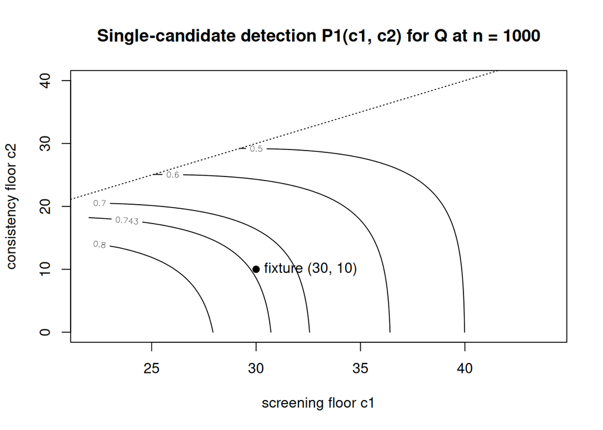

```r
g1 <- seq(22, 44, by = 0.5); g2 <- seq(0, 40, by = 0.5)
Z <- outer(g1, g2, Vectorize(function(a, b)
  if (b > a) NA_real_ else detect1(a, b, tQ, sQ1)))
contour(g1, g2, Z, levels = c(.5, .6, .7, .743, .8, .9, .95),
        xlab = "screening floor c1", ylab = "consistency floor c2",
        main = "Single-candidate detection P1(c1, c2) for Q at n = 1000")
points(30, 10, pch = 19); text(30, 10, "  fixture (30, 10)", adj = 0)
abline(0, 1, lty = 3)
```

Reading the outputs. The channel table is the section’s core: at the fixture floors the $Q$ channel detects at $0.738$ ($n = 1000$) while the $Q$-neutral (ITT) channel *also* clears at $0.55$ — the two rates a $(c_1, c_2)$ choice must trade, with $Q^c$ mild below both. The trade-off table walks $c_1$ across the gap and shows the exchange rate explicitly; the separation printout gives the $n$ at which chosen $(\rho, \alpha)$ pairs become jointly feasible; and the contour displays the full level sets of $P_1(c_1, c_2)$ with the fixture marked — flat in $c_2$ well below the diagonal, bending as $c_2$ approaches $c_1$ where replication takes over. Family declaration for a real family is this section composed with competition: each member is one channel with its purity-determined mean, and the family rate is the joint exceedance the next recipes compute. In policy-learning terms (Section 10.5) the floor thresholds the conditional mean $\beta(g)$, not the value $P(g)\,\beta(g)$ — and on this fixture the value is maximized by the whole sample, so value-ranking could not separate $Q$: the formal reason the procedure is mean-thresholding rather than welfare maximization.

## 5.9 A three-candidate warm-up, read line by line

Before the full worked example, a minimal geometry that shows what the recipes return and how to read them. Three candidates at the fixture’s means and measured scale: $Q$ itself; an overlapping proxy $P$ (prevalence $0.45$, sharing probability mass $0.28$ with $Q$, hence purity $P(Q \mid P) = 0.28/0.45 = 0.622$); and a near-duplicate $D \subset Q$ (prevalence $0.31$, purity $1$). SEs use the computed $\sigma[\hat\beta_{1000}(Q)] = 13.991$ and are scaled by the balanced-arms prevalence rule $\sigma[\hat\beta(H)] = \sigma[\hat\beta(Q)]\sqrt{\pi_Q/\pi_H}$; correlations are the $\sigma$-overlap block (per Section 4 Level 3, the fitted-SE anchor already carries the Level 4 variance component; the covariance refinement of Section 4.4 applies when DGM moments are in hand).

**The scale rule’s standing assumption, stated.** The prevalence rule $\sigma[\hat\beta(H)] = \sigma[\hat\beta(Q)]\sqrt{\pi_Q/\pi_H}$ — used here, in Section 5.8, and in Section 6 — is exact only if the Level 4 bracket $\sigma^2 + V_g[\mu_0] + \tfrac12 V_g[\tau] + C_g[\mu_0, \tau]$ is **constant across candidates**, since Section 4.4 gives $\operatorname{Var}[\hat\beta(g)] = V_{\mathrm{DM}}(g)/(nP(g))$ with a region-specific bracket. It is not constant: the Level 3 measurement puts it at $0.94$–$1.09$ of the $\sigma$-only value across regions, about $\pm4\%$ in the standard deviation. The consequences are bounded and worth carrying: channel detection rates move by roughly one point and the sample-size threshold $n^\ast$ of Section 5.8 by about $\pm 9\%$ (it scales with the variance).

Two further points about that heterogeneity, both quantitative. First, under a non-constant bracket the *choice* of anchor region matters in principle, because the rule is exact where the anchor sits and drifts away from it — and $Q$ is atypical in one respect: at purity $1$, $V_Q[\tau] = 0$ (as at $Q^c$), while every mixed-purity region carries $\tfrac12 V_g[\tau] = \tfrac12\beta_{\mathrm{int}}^2 p(1-p) > 0$, so a $Q$-anchored rule systematically *understates* mixed-purity scales. Second, the magnitude settles the matter here: direct enumeration gives $V_{\mathrm{eff}} = 67{,}454$, an effective bracket of $16{,}863.44$ (per-subject effective standard deviation $129.9$). Two CATE-dependent terms enter that bracket, and only one of them is bounded. The variance term satisfies $\tfrac12 V_g[\tau] \le \beta_{\mathrm{int}}^2/8 = 23.6$, attained at $p = 1/2$; on $\mathcal S$ it equals $21.33$. The cross term $C_g[\mu_0,\tau]$ admits no such bound — it scales with $\beta_{\mathrm{int}}$ times the prognostic contrast between $Q$ and its complement — and on $\mathcal S$ it equals $-33.59$, larger in magnitude than the bound on the first and opposite in sign. Both are negligible against a bracket of $16{,}863$ ($0.13\%$ and $0.20\%$), and on $Q$ and $Q^c$ both vanish identically because $\tau$ is constant there. The CATE contribution is therefore negligible on this fixture, which means the measured $0.94$–$1.09$ spread is essentially all **prognostic** ($V_g[\mu_0]$), and the anchor choice is immaterial numerically even though it is not immaterial in principle. Every computed rate in this document that uses the prevalence rule inherits that tolerance; the exact alternative is to evaluate the Level 4 diagonal per candidate, which requires the fixture’s noise scale and prognostic surface as enumerable inputs.

```r
set.seed(20260824)   # pins pmvnorm's quasi-MC randomization for the gap readout
library(mvtnorm)
tauQc <- .anchor$m_Qc; bint <- .anchor$beta_int   # oriented
c1 <- 30; seQ <- .anchor$seQ1000; piQ <- .anchor$piQ
cand <- data.frame(
  name = c("Q", "P (overlap proxy)", "D (near-dup, subset of Q)"),
  pi   = c(piQ, 0.45, 0.31),
  piQg = c(1.00, 0.28/0.45, 1.00))          # P(Q | g)
cand$beta <- tauQc + bint * cand$piQg
cand$se   <- seQ * sqrt(piQ / cand$pi)
ov <- matrix(c(piQ, 0.28, 0.31,
               0.28, 0.45, 0.28*0.31/piQ,   # |P∩D| via D ⊂ Q composition
               0.31, 0.28*0.31/piQ, 0.31), 3, 3)
R  <- ov / sqrt(outer(cand$pi, cand$pi))
Sg <- R * outer(cand$se, cand$se)
p_marg <- pnorm(c1, cand$beta, cand$se, lower.tail = FALSE)
p_fam  <- 1 - pmvnorm(upper = rep(c1, 3), mean = cand$beta, sigma = Sg,
                      algorithm = GenzBretz(abseps = 1e-6))
sel <- vapply(1:3, function(m) {
  A <- rbind(diag(3)[m, ],
             do.call(rbind, lapply(setdiff(1:3, m),
                                   function(j) diag(3)[m, ] - diag(3)[j, ])))
  as.numeric(pmvnorm(lower = c(c1, 0, 0), upper = rep(Inf, 3),
                     mean = as.numeric(A %*% cand$beta),
                     sigma = A %*% Sg %*% t(A),
                     algorithm = GenzBretz(abseps = 1e-6)))
}, numeric(1))
out <- data.frame(candidate = cand$name,
                  beta_oriented = round(cand$beta, 3),
                  se = round(cand$se, 3),
                  marginal_clearance = round(p_marg, 4),
                  selection_prob = round(sel, 4))
knitr::kable(out, caption = sprintf(
  "Warm-up at n = 1000: family declaration %.4f; selection identity gap %.1e.",
  as.numeric(p_fam), abs(sum(sel) - as.numeric(p_fam))))
```

Warm-up at n = 1000: family declaration 0.8439; selection identity gap 5.2e-06.

| candidate | beta_oriented | se | marginal_clearance | selection_prob |
| --- | --- | --- | --- | --- |
| Q | 40.000 | 13.991 | 0.7626 | 0.2975 |
| P (overlap proxy) | 34.808 | 12.243 | 0.6527 | 0.1889 |
| D (near-dup, subset of Q) | 40.000 | 14.751 | 0.7511 | 0.3576 |

Reading the table. **Column `beta_oriented`** is the mixture mean: $Q$ and $D$ both sit at $40$ (both have purity $1$), $P$ at $34.81$. **Column `se`** is the prevalence-scaled measured scale: smaller regions are noisier, so $D$ ($\pi = 0.31$) carries the largest SE. **Column `marginal_clearance`** treats each candidate alone: $Q$ clears the floor $76.3\%$ of the time, $D$ $75.1\%$, $P$ $65.3\%$. **Column `selection_prob`** is the joint answer, and it is *not* proportional to the marginals: $D$ takes the largest share ($0.358$) despite the smaller marginal clearance, because at equal means the *noisier* candidate wins the argmax more often — the Gaussian-level mechanism behind the observed tendency of the identifier to return small, noise-favored regions. The three selection probabilities sum to the family declaration rate ($0.8439$) up to the printed quadrature gap — an internal consistency identity, not a new assumption. Finally, family declaration ($0.844$) exceeds the best marginal ($0.763$): competition helps *declaration* even as it dilutes any single candidate’s *selection*.

### 5.9.1 Adding the consistency floor, and the ITT and $Q^c$ channels

The warm-up table above is screening-only. Two additions complete it in the direction of Section 5.8: the consistency floor, and the two ideal channels as explicit family members.

```r
set.seed(20260826)
P1_3 <- vapply(seq_len(3), function(m)
  detect1(c1, 10, cand$beta[m], cand$se[m]), numeric(1))
rt3 <- forestsearch::fs_sym_root(2 * Sg, scale = 1)
Rg <- 2e5
fam_split <- function(mu, root, Mloc, c2v) {
  V1 <- matrix(rnorm(Rg*Mloc), Rg, Mloc) %*% t(root) + rep(mu, each = Rg)
  V2 <- matrix(rnorm(Rg*Mloc), Rg, Mloc) %*% t(root) + rep(mu, each = Rg)
  mean(rowSums((V1 + V2 >= 2*c1) & (V1 >= c2v) & (V2 >= c2v)) > 0)
}
fam10 <- fam_split(cand$beta, rt3, 3, 10)
fam25 <- fam_split(cand$beta, rt3, 3, 25)
# Augment with the ITT rule S (prevalence 1) and the complement Qc
piQ <- .anchor$piQ; sQ1 <- .anchor$seQ1000
beta5 <- c(cand$beta, .anchor$m_ITT, .anchor$m_Qc)
prev5 <- c(cand$pi, 1, 1 - piQ)
se5   <- c(cand$se, sQ1*sqrt(piQ), sQ1*sqrt(piQ/(1-piQ)))
ov5 <- matrix(0, 5, 5)
ov5[1:3, 1:3] <- ov
ov5[4, ] <- ov5[, 4] <- prev5            # S overlaps everything at P(g)
ov5[5, 1:3] <- ov5[1:3, 5] <- c(0, 0.45 - 0.28, 0)   # Qc: none with Q, D
ov5[5, 4] <- ov5[4, 5] <- 1 - piQ; ov5[5, 5] <- 1 - piQ
diag(ov5)[1:3] <- cand$pi
R5 <- ov5 / sqrt(outer(prev5, prev5))
S5 <- R5 * outer(se5, se5)
rt5 <- forestsearch::fs_sym_root(2 * S5, scale = 1)
fam5_10 <- fam_split(beta5, rt5, 5, 10)
scr5 <- pnorm(c1, beta5, se5, lower.tail = FALSE)
P1_5 <- vapply(seq_len(5), function(m) detect1(c1, 10, beta5[m], se5[m]),
               numeric(1))
knitr::kable(data.frame(
  member = c(as.character(cand$name), "S (ITT rule)", "Qc (complement)"),
  beta = round(beta5, 3), se = round(se5, 3),
  screen_only = round(scr5, 3), P1_c1_30_c2_10 = round(P1_5, 3)),
  row.names = FALSE, caption =
  "The warm-up family with the two ideal channels added, at floors (30, 10).")
```

The warm-up family with the two ideal channels added, at floors (30, 10).

| member | beta | se | screen_only | P1_c1_30_c2_10 |
| --- | --- | --- | --- | --- |
| Q | 40.000 | 13.991 | 0.763 | 0.738 |
| P (overlap proxy) | 34.808 | 12.243 | 0.653 | 0.636 |
| D (near-dup, subset of Q) | 40.000 | 14.751 | 0.751 | 0.722 |
| S (ITT rule) | 30.992 | 8.213 | 0.548 | 0.546 |
| Qc (complement) | 26.255 | 10.145 | 0.356 | 0.350 |

```r
cat(sprintf("Family single-split declaration: 3-candidate %.4f (c2=10; MC SE %.4f) / %.4f (c2=25; MC SE %.4f); screening-only %.4f.\n",
            fam10, .mc_se_prop(fam10, Rg), fam25, .mc_se_prop(fam25, Rg),
            as.numeric(p_fam)))
```

```
#> Family single-split declaration: 3-candidate 0.8285 (c2=10; MC SE 0.0008) / 0.7096 (c2=25; MC SE 0.0010); screening-only 0.8439.
```

```r
cat(sprintf("5-member family with ITT and Qc channels, c2=10: %.4f (MC SE %.4f).\n",
            fam5_10, .mc_se_prop(fam5_10, Rg)))
```

```
#> 5-member family with ITT and Qc channels, c2=10: 0.8779 (MC SE 0.0007).
```

Reading the additions. The consistency floor at $c_2 = 10$ trims the three-candidate family from the screening-only $0.844$ by the sum-forcing mechanism of Section 5.8, and $c_2 = 25$ shows the floor biting in earnest. Adding the two ideal channels raises family declaration further — the ITT rule alone contributes a $0.55$-per-family clearance route at these floors — which is the warm-up-scale demonstration of the section’s central point: **“overall detection” is a property of the channel set, and the $(c_1, c_2)$ pair prices every channel simultaneously through its purity-determined mean.** The three-class structure (truth, proxy, near-duplicate) governs *which* member is selected; the ITT and $Q^c$ channels govern how often *something* clears when the informative members are absent or weak.

## 5.10 Design calculators

The recipes invert. Sample size for a target marginal clearance of $Q$:

```r
n_for <- function(target, se_n1000 = .anchor$seQ1000, mu = 40, c1 = 30)
  1000 * (se_n1000 * qnorm(target) / (mu - c1))^2
cat(sprintf("n for %d%% marginal clearance of Q at floor 30: %s\n",
            c(80L, 90L, 95L),
            format(round(n_for(c(.80, .90, .95))), big.mark = ",")), sep = "")
```

```
#> n for 80% marginal clearance of Q at floor 30: 1,387
#> n for 90% marginal clearance of Q at floor 30: 3,215
#> n for 95% marginal clearance of Q at floor 30: 5,296
```

Family-level and selection-level counterparts invert the corresponding functionals by the same one-dimensional search; Monte Carlo error budgets for grid design follow from computed rates rather than convention.

# 6 A detailed worked example: the maxeffCons MR design at n = 500

This section carries the machinery end to end against a specific committed design: `sim_fs_maxeffCons_mr_md40_knoise0_n500_batch_1_1000.qmd`. Every input is taken from that document’s own setup chunks; every output is stated together with the report column it should be compared against.

## 6.1 Step 1 — the design under study

From the driver’s setup, verbatim: $n = 500$ per replicate; the committed alternative cell (`target_md_harm = -40` raw, oriented $+40$ in $Q$); floors `md_threshold = 30`, `md_consistency = 10`; consistency gate $\hat p_{\mathrm{cons}} \ge 0.90$ over `fs.splits = 400` random splits; `n.min = 60` (a $60/500 = 12\%$ prevalence floor on candidates); `maxk = 2` (conjunctions of at most two conditions); `sg_focus = "maxeffCons"` — in the driver’s own words, “highest effect meeting the consistency rate”; MR with 5000 draws; no added noise covariates. The candidate cuts are the deliberate part of the design: J $= 10$ quantile grids on `age` and `preanti` **replace** the default cuts, so the true boundaries ($34$ and $744.5$) are *not representable*; the driver documents the best achievable rule as `age > 33 & preanti <= 677.9` at Jaccard $0.882$ against $Q$, and gives the grid quantile positions (the $33$ cut at the $5/11 = 45.5\%$ age quantile; the preanti grid $0, 0, 0, 0, 55.8, 214.1, 432, 677.9, 872.8, 1070.5$ at the $k/11$ quantiles, so $677.9$ sits at $72.7\%$). Here and throughout, the **Jaccard index** of a rule $g$ against $Q$ is
$$J(g, Q) \;=\; \frac{P(g \cap Q)}{P(g \cup Q)},$$
the overlap as a fraction of the union — equal to $1$ exactly when $g = Q$, and tied to the classification identities of Part I, Corollary (v), by the exact relation $1/J = 1/\mathrm{sens} + 1/\mathrm{PPV} - 1$: the driver’s rule-recovery metric is the harmonic composite of recovery and purity.

Its report tabulates, per batch: the status trichotomy (`DETECTED / NO-DETECTION / CONFIG-ERROR`); identified-subgroup sizes (`n_harm`); the realized-rule frequency table (`sg_def`) and covariate-involvement shares; classification (sens/spec/PPV/NPV); and the estimation table scoring oracle/naive/MR against the exact $\beta(\hat H)$, the oracle refit, and the structural and fitted targets. Those are exactly the quantities the recipes predict.

## 6.2 Step 2 — what must be specified, and what the driver already supplies

The recipes need five inputs. The driver supplies four directly: the oriented effects ($\tau_{Q^c} = +26.255$, $\beta_{\mathrm{int}} = +13.745$, hence purity translation $P(Q \mid g) \ge 0.272$ for true clearance — the driver’s own “27.2%” remark); the sample size and floors; the selection rule (maxeffCons); and the scale (the computed $\sigma[\hat\beta_{1000}(Q)] = 13.991$, which the Level 3 fitted-SE observation confirms as a population-effective scale, rescaled to $n = 500$ by $\sqrt 2$). The fifth input — **the candidate family and the joint covariate law that determines every $P(g)$, $P(Q \mid g)$, and overlap** — is the one forestsearch regenerates per replicate, so a prediction must either condition on a realized family (Section 6.8) or construct a scenario satisfying the fixed-family requirements. This example does the latter, using only quantities the driver itself documents.

## 6.3 Step 3 — constructing the scenario from documented anchors

Cross the two true-region axes at their *representable* resolutions. Age takes three categories $\{\le 33,\ (33, 34],\ > 34\}$ — the family can cut at $33$ (a grid cut) but not at $34$ (the true boundary, absent from the grid). Preanti takes three categories $\{\le 677.9,\ (677.9, 744.5],\ > 744.5\}$ — cut at $677.9$ representable, true boundary $744.5$ not. Marginals come from the documented quantile positions ($P(\text{age} > 33) = 1 - 5/11 = 0.545$; $P(\text{age} > 34) = 0.50$, the median; $P(\text{preanti} \le 677.9) = 8/11 = 0.727$; $P(\text{preanti} \le 744.5) = 0.75$, the q75 default). The $3 \times 3$ joint below satisfies **all** the documented anchors simultaneously — the four marginals, $P(Q) = 0.3446$, and Jaccard of the best representable rule against $Q$ equal to $0.8820$ — and the chunk asserts each one. A third, stylized covariate $V$ (prevalence $0.42$, drawn independently of the $Q$-defining covariates) stands in for the distractor pool. The word *independent* is used advisedly here and only here: at the DGM level there is genuine randomness, and independent generation makes $V$’s regions $Q$-neutral **in expectation**, with sampling fluctuation about that value in any realized cohort — whereas on the fixed `df_super` neutrality is the exact count condition $|g \cap Q| = \pi |g|$ of §2. The distractors of the real design include `str2`, which nests inside the true partner condition and is *not* independently generated — the stylization is stated, not hidden. Candidates are all single conditions and cross-variable pairs over the three representable cuts (both sides), pruned at the $12\%$ `n.min` floor.

```r
library(mvtnorm)
set.seed(20260825)
tauQc <- .anchor$m_Qc; bint <- .anchor$beta_int        # oriented
c1 <- 30; c2 <- 10; n_rep <- 500; pcons_gate <- 0.90
seQ1000 <- .anchor$seQ1000; piQ_fix <- .anchor$piQ
# 3x3 joint: rows age (<=33, (33,34], >34); cols preanti (<=677.9,
# (677.9,744.5], >744.5). Hand-solved to hit every documented anchor.
J3 <- matrix(c(0.3553, 0.0121, 0.0876,
               0.0360, 0.0020, 0.0070,
               0.3357, 0.0089, 0.1554), 3, 3, byrow = TRUE)
stopifnot(abs(sum(J3) - 1) < 1e-12,
          abs(rowSums(J3) - c(0.455, 0.045, 0.500)) < 1e-12,
          abs(colSums(J3) - c(0.727, 0.023, 0.250)) < 1e-12)
PQ <- J3[3, 1] + J3[3, 2]                    # Q = age>34 & pre<=744.5
stopifnot(abs(PQ - piQ_fix) < 1e-4)
gstar_P <- J3[2, 1] + J3[3, 1]               # g* = age>33 & pre<=677.9
jac <- J3[3, 1] / (gstar_P + PQ - J3[3, 1])
stopifnot(abs(jac - 0.882) < 1e-3)
cat(sprintf("Scenario anchors: P(Q) = %.4f; Jaccard(g*, Q) = %.4f (driver: 0.882)\n",
            PQ, jac))
```

```
#> Scenario anchors: P(Q) = 0.3446; Jaccard(g*, Q) = 0.8820 (driver: 0.882)
```

```r
# 18 cells: 9 (age x pre) x V in {1, 0}, V independent, P(V=1) = .42
pV <- 0.42
cells <- expand.grid(a = 1:3, p = 1:3, v = 1:0)
cells$prob <- J3[cbind(cells$a, cells$p)] * ifelse(cells$v == 1, pV, 1 - pV)
cells$inQ  <- cells$a == 3 & cells$p <= 2
# Candidate conditions on representable cuts (both sides) + V
conds <- list(`age>33` = cells$a >= 2, `age<=33` = cells$a == 1,
              `pre<=677.9` = cells$p == 1, `pre>677.9` = cells$p >= 2,
              `V=1` = cells$v == 1, `V=0` = cells$v == 0)
fam <- c(lapply(names(conds), function(nm) list(nm = nm, m = conds[[nm]])),
         unlist(lapply(list(c(1,3), c(1,4), c(2,3), c(2,4),
                            c(1,5), c(1,6), c(2,5), c(2,6),
                            c(3,5), c(3,6), c(4,5), c(4,6)),
   function(ix) list(list(nm = paste(names(conds)[ix], collapse = " & "),
                          m = conds[[ix[1]]] & conds[[ix[2]]]))),
   recursive = FALSE))
Pg  <- vapply(fam, function(f) sum(cells$prob[f$m]), numeric(1))
keep <- Pg >= 0.12                                  # n.min = 60 of 500
fam <- fam[keep]; Pg <- Pg[keep]; M <- length(fam)
lab <- vapply(fam, `[[`, character(1), "nm")
PQg <- vapply(fam, function(f) sum(cells$prob[f$m & cells$inQ]), numeric(1)) / Pg
beta_g <- tauQc + bint * PQg
se_g   <- seQ1000 * sqrt(2) * sqrt(piQ_fix / Pg)    # n = 500 anchor scaling
sens_g <- vapply(fam, function(f) sum(cells$prob[f$m & cells$inQ]), numeric(1)) / PQ
spec_g <- vapply(fam, function(f) 1 - sum(cells$prob[f$m & !cells$inQ]) / (1 - PQ),
                 numeric(1))
ovl <- outer(seq_len(M), seq_len(M), Vectorize(function(i, j)
  sum(cells$prob[fam[[i]]$m & fam[[j]]$m])))
Rho <- ovl / sqrt(outer(Pg, Pg))
Sg  <- Rho * outer(se_g, se_g)
tab3 <- data.frame(candidate = lab, prevalence = round(Pg, 4),
                   purity_PQg = round(PQg, 4), beta = round(beta_g, 2),
                   se_n500 = round(se_g, 1),
                   clears_floor = ifelse(beta_g >= c1, "yes", "no"))
knitr::kable(tab3[order(-tab3$beta), ], row.names = FALSE, caption = sprintf(
  "The scenario family (M = %d after the 12%% floor): mixture means, anchored scales, and the purity translation of the floor.", M))
```

The scenario family (M = 16 after the 12% floor): mixture means, anchored scales, and the purity translation of the floor.

| candidate | prevalence | purity_PQg | beta | se_n500 | clears_floor |
| --- | --- | --- | --- | --- | --- |
| age>33 & pre<=677.9 | 0.3717 | 0.9031 | 38.67 | 19.1 | yes |
| age>33 | 0.5450 | 0.6323 | 34.95 | 15.7 | yes |
| age>33 & V=1 | 0.2289 | 0.6323 | 34.95 | 24.3 | yes |
| age>33 & V=0 | 0.3161 | 0.6323 | 34.95 | 20.7 | yes |
| pre<=677.9 | 0.7270 | 0.4618 | 32.60 | 13.6 | yes |
| pre<=677.9 & V=1 | 0.3053 | 0.4618 | 32.60 | 21.0 | yes |
| pre<=677.9 & V=0 | 0.4217 | 0.4618 | 32.60 | 17.9 | yes |
| V=1 | 0.4200 | 0.3446 | 30.99 | 17.9 | yes |
| V=0 | 0.5800 | 0.3446 | 30.99 | 15.3 | yes |
| age>33 & pre>677.9 | 0.1733 | 0.0514 | 26.96 | 27.9 | no |
| pre>677.9 | 0.2730 | 0.0326 | 26.70 | 22.2 | no |
| pre>677.9 & V=0 | 0.1583 | 0.0326 | 26.70 | 29.2 | no |
| age<=33 | 0.4550 | 0.0000 | 26.26 | 17.2 | no |
| age<=33 & pre<=677.9 | 0.3553 | 0.0000 | 26.26 | 19.5 | no |
| age<=33 & V=1 | 0.1911 | 0.0000 | 26.26 | 26.6 | no |
| age<=33 & V=0 | 0.2639 | 0.0000 | 26.26 | 22.6 | no |

Reading the family table. The purity column *is* the mean column in disguise (Proposition 1), and the floor line falls at purity $0.2724$ — below the marginal prevalence $0.3446$, so **nine of the sixteen candidates have true effects above the floor, including the pure distractors** $V{=}1$ and $V{=}0$ at $\beta = 30.99$. On this pathway the screening floor does not separate signal from noise regions; it separates regions *depleted* of $Q$ from everything else. The best representable rule $g^\ast$ leads at $\beta = 38.67$ (purity $0.903$), $1.33$ units below the unrepresentable truth — the price of the J-grid design, quantified before any simulation.

## 6.4 Step 4 — predictions, each mapped to its report column

The maxeffCons rule is: among candidates passing the consistency gate, select the one with the largest fitted effect; declare `NO-DETECTION` if none passes. The idealized computation below replaces the $\hat p_{\mathrm{cons}} \ge 0.90$ multi-split gate with the single-split event $\{\hat\beta^{[1]} + \hat\beta^{[2]} \ge 2c_1,\ \min(\hat\beta^{[1]}, \hat\beta^{[2]}) \ge c_2\}$ — again the half-sample fitted effects — and evaluates everything on the known Gaussian law by Monte Carlo (Level 2 numerics; $2 \times 10^5$ draws, so rate SEs are $\approx 0.001$). Direction of the idealization, stated: with $c_2 = 10$ sitting far below every candidate mean (the driver’s open question D2 — the consistency floor is non-discriminating on this cell), the per-split floor events are nearly always satisfied and both gates reduce to variants of “the effect replicates above threshold”; a demanding $\hat p_{\mathrm{cons}} \ge 0.90$ over 400 splits is *stricter* than one split, so at fixed family the computed detection rate is an upper benchmark and the computed selection law shifts mass toward stable (larger, higher-mean) candidates relative to the real gate; the far larger real family pushes detection the other way and dominates it here.

```r
set.seed(20260825)   # pinned: identical to the state formerly inherited from L1653
Rdraw <- 2e5
# Complement pairs make the population law EXACTLY rank-deficient: for any
# cut, P(g+)c(g+) + P(g-)c(g-) is the full-sample coefficient vector, so the
# candidate covariance is a singular Gram matrix (the Level 4 PSD fact, made
# concrete). Sample by eigendecomposition; degenerate directions get zero
# variance, which enforces the linear constraints exactly.
root_half <- forestsearch::fs_sym_root(Sg, scale = 2)  # cov = 2*Sg
W1 <- matrix(rnorm(Rdraw * M), Rdraw, M) %*% t(root_half) +
      rep(beta_g, each = Rdraw)
W2 <- matrix(rnorm(Rdraw * M), Rdraw, M) %*% t(root_half) +
      rep(beta_g, each = Rdraw)
Bhat <- (W1 + W2) / 2                   # full-sample effects, exact law N(beta, Sg)
pass <- (W1 + W2 >= 2 * c1) & (W1 >= c2) & (W2 >= c2)
det  <- rowSums(pass) > 0
Bmask <- Bhat; Bmask[!pass] <- -Inf
winner <- max.col(Bmask, ties.method = "first"); winner[!det] <- NA_integer_
P1 <- colMeans(pass)
p_sel <- tabulate(winner[det], M) / Rdraw
det_rate <- mean(det)
sel_c <- p_sel / det_rate                       # selection | detection
EnH   <- n_rep * sum(sel_c * Pg)                # expected |Hhat| | detection
Esens <- sum(sel_c * sens_g); Espec <- sum(sel_c * spec_g)
Eppv  <- sum(sel_c * PQg)
Enpv  <- sum(sel_c * vapply(seq_len(M), function(m) {
  pHc <- 1 - Pg[m]; (pHc - (PQ - PQg[m] * Pg[m])) / pHc }, numeric(1)))
EbetaH <- sum(sel_c * beta_g)
noise  <- Bhat - rep(beta_g, each = Rdraw)
Enaive_bias <- mean(noise[cbind(which(det), winner[det])])
mass_below <- sum(sel_c[beta_g < c1])          # selections on true-mean-below-floor rules
top <- order(-p_sel)[1:6]
knitr::kable(data.frame(candidate = lab[top],
                        P1_single_split = round(P1[top], 3),
                        P_selected = round(p_sel[top], 3),
                        sel_given_det = round(sel_c[top], 3)),
             row.names = FALSE, caption = sprintf(
  "Top of the predicted selection distribution (detection rate %.3f, MC SE %.4f). Compare P_selected against the driver's realized-rule (sg_def) frequency table.",
  det_rate, .mc_se_prop(det_rate, Rdraw)))
```

Top of the predicted selection distribution (detection rate 0.964, MC SE 0.0004). Compare P_selected against the driver’s realized-rule (sg_def) frequency table.

| candidate | P1_single_split | P_selected | sel_given_det |
| --- | --- | --- | --- |
| age>33 & V=1 | 0.498 | 0.153 | 0.159 |
| age>33 & pre<=677.9 | 0.620 | 0.131 | 0.135 |
| age<=33 & V=1 | 0.361 | 0.115 | 0.119 |
| pre>677.9 & V=0 | 0.361 | 0.112 | 0.116 |
| age>33 & V=0 | 0.530 | 0.098 | 0.102 |
| age>33 & pre>677.9 | 0.368 | 0.091 | 0.094 |

```r
knitr::kable(data.frame(
  quantity = c("detection rate (DETECTED share)",
               "E[|Hhat|] given detection (n_harm mean)",
               "E[sens]", "E[spec]", "E[PPV]", "E[NPV]",
               "E[beta(Hhat)] oriented (betaHhat_H mean)",
               "E[naive - beta(Hhat)] (naive bias vs beta(Hhat))",
               "selection mass on rules with true mean below the floor"),
  predicted = round(c(det_rate, EnH, Esens, Espec, Eppv, Enpv,
                      EbetaH, Enaive_bias, mass_below), 3)),
  row.names = FALSE, caption =
  "Scenario predictions with their driver-report comparison targets in parentheses.")
```

Scenario predictions with their driver-report comparison targets in parentheses.

| quantity | predicted |
| --- | --- |
| detection rate (DETECTED share) | 0.964 |
| E[\|Hhat\|] given detection (n_harm mean) | 132.843 |
| E[sens] | 0.329 |
| E[spec] | 0.767 |
| E[PPV] | 0.359 |
| E[NPV] | 0.695 |
| E[beta(Hhat)] oriented (betaHhat_H mean) | 31.193 |
| E[naive - beta(Hhat)] (naive bias vs beta(Hhat)) | 30.936 |
| selection mass on rules with true mean below the floor | 0.468 |

Reading the predictions, line by line.

**Detection.** The computed rate is $0.963$: with nine candidate means above the floor and half-sample SEs of $19$–$40$, *some* candidate clears on nearly every replicate. The committed real-family measurement for this design at $n = 500$ is $1000/1000$ (Section 9.4, verified by tabulating the stored payload) — higher still, in exactly the direction the family-size caveat below predicts — and the driver’s own status table is this prediction’s comparison target. Detection on this cell is not evidence of finding $Q$; the interesting prediction is *what* gets selected.

**Winner size and classification.** $\mathbb E[\,|\hat H|\,]$ is the selection-weighted prevalence times $n$ — compare to the `n_harm` mean in the identified-subgroup-sizes callout — and expected sens/spec/PPV/NPV are selection-weighted overlaps with $Q$, comparable to the identification table. Because $g^\ast$ carries sens $= 0.974$ and PPV $= 0.903$, the predictions sit high exactly to the extent selection concentrates on it; the shortfall from those ceilings measures the noise-selection share.

**The conditional estimand and the naive bias.** $\mathbb E[\beta(\hat H)]$ is the selection-weighted mixture mean (compare: oriented `betaHhat_H` mean over detected replicates), and the naive-bias forecast is the mean noise of the winner (compare: the naive row’s “vs $\beta(\hat H)$” column). The latter is the winner’s-curse functional of `oracle_design.R`, now with this design’s own means and covariances as inputs.

**What this scenario cannot predict** — stated as sharply as what it can. The real family is far larger (six continuous covariates at ten cuts each, both sides, plus seven binaries, under `maxk = 2` and the viability floors), so real selection mass is diluted across many more low-purity competitors: relative to this $M = 16$ scenario, expect *lower* concentration on $g^\ast$, *smaller* winners, and *larger* naive bias. The classification consequences do **not** move together, and it is worth resisting the natural guess that they do: smaller, purer winners push sensitivity and NPV *below* these predictions while pushing PPV and specificity *above* them. That split is what both completed runs record (Section 9 at $n = 700$, Section 9.4 at $n = 500$); the magnitudes require either the realized family (Section 6.8) or a larger constructed one. And the multi-split gate strengthens the consistency requirement relative to the single split, filtering marginal passers; both idealizations are Level 5 rungs with signs attached, not silent gaps.

## 6.5 Step 4b — how much of this depends on the unpinned interior

The scenario is pinned by the driver’s documented anchors — the four marginals, $P(Q) = 0.3446$, and $\mathrm{Jaccard}(g^\ast, Q) = 0.882$ — but those anchors do not determine the $3\times3$ joint uniquely, and the distractor $V$ was stylized outright. A prediction whose attributions depended on the unpinned parts would be an artifact, so the freedom is enumerated and swept rather than left implicit.

A $3\times3$ table with fixed row and column marginals has four free cells; the two anchors ($P(Q)$ and the Jaccard) consume two, leaving exactly **two** free parameters, which may be taken as $x = J_{31} = P(\text{age} > 34,\ \text{preanti} \le 677.9)$ and $y = J_{22}$. Every other cell follows in closed form: $J_{32} = \pi - x$, $J_{33} = 0.1554$, $J_{21} = x/0.882 - \pi$, $J_{23} = 0.045 - J_{21} - y$, $J_{11} = 0.727 - J_{21} - x$, $J_{12} = 0.023 - y - (\pi - x)$, $J_{13} = 0.0946 - J_{23}$. Non-negativity confines $x$ to roughly $[0.324, 0.342]$ at the base $y$; the Step 3 table sits at $(x, y) = (0.3357, 0.0020)$, mid-range. The third stylized quantity is $P(V = 1) = 0.42$.

```r
# This chunk draws random numbers; it saves and restores the RNG state so
# that every downstream chunk reproduces exactly as before its insertion.
.rng_state <- .Random.seed
build_J <- function(x, y) {
  J21 <- x/0.882 - piQ_fix; J <- matrix(0, 3, 3)
  J[3, ] <- c(x, piQ_fix - x, 0.1554)
  J[2, ] <- c(J21, y, 0.045 - J21 - y)
  J[1, ] <- c(0.727 - J21 - x, 0.023 - y - (piQ_fix - x),
              0.0946 - (0.045 - J21 - y))
  stopifnot(all(J >= -1e-12), abs(sum(J) - 1) < 1e-9,
            max(abs(rowSums(J) - c(.455, .045, .500))) < 1e-9,
            max(abs(colSums(J) - c(.727, .023, .250))) < 1e-9)
  J
}
predict_scn <- function(x, y, pV, R = 2e5) {
  set.seed(20260827)          # common random numbers across variants
  J3 <- build_J(x, y)
  cel <- expand.grid(a = 1:3, p = 1:3, v = 1:0)
  cel$prob <- J3[cbind(cel$a, cel$p)] * ifelse(cel$v == 1, pV, 1 - pV)
  cel$inQ  <- cel$a == 3 & cel$p <= 2
  cd <- list(cel$a >= 2, cel$a == 1, cel$p == 1, cel$p >= 2,
             cel$v == 1, cel$v == 0)
  mem <- c(cd, lapply(list(c(1,3), c(1,4), c(2,3), c(2,4), c(1,5), c(1,6),
                           c(2,5), c(2,6), c(3,5), c(3,6), c(4,5), c(4,6)),
                      function(ix) cd[[ix[1]]] & cd[[ix[2]]]))
  Pg <- vapply(mem, function(m) sum(cel$prob[m]), numeric(1))
  k <- Pg >= 0.12; mem <- mem[k]; Pg <- Pg[k]; M <- length(mem)
  inQ <- vapply(mem, function(m) sum(cel$prob[m & cel$inQ]), numeric(1))
  PQg <- inQ / Pg; bet <- tauQc + bint * PQg
  se  <- seQ1000 * sqrt(2) * sqrt(piQ_fix / Pg)
  ovl <- outer(seq_len(M), seq_len(M), Vectorize(function(i, j)
    sum(cel$prob[mem[[i]] & mem[[j]]])))
  Sg <- (ovl / sqrt(outer(Pg, Pg))) * outer(se, se)
  rt <- forestsearch::fs_sym_root(Sg, scale = 2)
  A <- matrix(rnorm(R*M), R, M) %*% t(rt) + rep(bet, each = R)
  B <- matrix(rnorm(R*M), R, M) %*% t(rt) + rep(bet, each = R)
  Bh <- (A + B)/2; ps <- (A + B >= 2*c1) & (A >= c2) & (B >= c2)
  dt <- rowSums(ps) > 0; Bm <- Bh; Bm[!ps] <- -Inf
  w <- max.col(Bm, ties.method = "first"); w[!dt] <- NA
  sc <- (tabulate(w[dt], M)/R) / mean(dt)
  c(detection = mean(dt), EnH = n_rep * sum(sc * Pg),
    sens = sum(sc * inQ/piQ_fix), ppv = sum(sc * PQg),
    EbetaH = sum(sc * bet),
    naive = mean((Bh - rep(bet, each = R))[cbind(which(dt), w[dt])]),
    below = sum(sc[bet < c1]))
}
grid <- data.frame(
  variant = c("base (Step 3)", "x = 0.325", "x = 0.341", "y = 0.0005",
              "y = 0.0060", "P(V=1) = 0.30", "P(V=1) = 0.55"),
  x  = c(.3357, .3250, .3410, .3357, .3357, .3357, .3357),
  y  = c(.0020, .0020, .0020, .0005, .0060, .0020, .0020),
  pV = c(.42, .42, .42, .42, .42, .30, .55))
sens_out <- do.call(rbind, lapply(seq_len(nrow(grid)), function(i)
  predict_scn(grid$x[i], grid$y[i], grid$pV[i])))
knitr::kable(cbind(grid["variant"], round(as.data.frame(sens_out), 3)),
  row.names = FALSE, caption = paste(
  "Sensitivity of the Step 4 predictions to the two free interior parameters",
  "and the stylized distractor prevalence. The base row reproduces Step 4 to",
  "Monte-Carlo tolerance (about 0.001 on rates)."))
```

Sensitivity of the Step 4 predictions to the two free interior parameters and the stylized distractor prevalence. The base row reproduces Step 4 to Monte-Carlo tolerance (about 0.001 on rates).

| variant | detection | EnH | sens | ppv | EbetaH | naive | below |
| --- | --- | --- | --- | --- | --- | --- | --- |
| base (Step 3) | 0.963 | 132.515 | 0.326 | 0.357 | 31.165 | 30.961 | 0.471 |
| x = 0.325 | 0.963 | 132.526 | 0.337 | 0.380 | 31.480 | 30.566 | 0.463 |
| x = 0.341 | 0.964 | 132.180 | 0.320 | 0.346 | 31.004 | 31.199 | 0.476 |
| y = 0.0005 | 0.963 | 132.515 | 0.326 | 0.357 | 31.165 | 30.961 | 0.471 |
| y = 0.0060 | 0.963 | 132.515 | 0.326 | 0.357 | 31.165 | 30.961 | 0.471 |
| P(V=1) = 0.30 | 0.962 | 125.641 | 0.310 | 0.364 | 31.265 | 32.150 | 0.458 |
| P(V=1) = 0.55 | 0.968 | 123.926 | 0.295 | 0.319 | 30.641 | 33.436 | 0.534 |

```r
.Random.seed <- .rng_state    # restore: downstream chunks are unaffected
```

## 6.6 Step 5 — the null-cell twin, predicted before it runs

The driver’s `null_cell = TRUE` switch sets $\beta_{\mathrm{int}} = 0$, so every region’s oriented mean collapses to the common treatment effect ($\approx +26.26$, the complement value). The same machinery then predicts the null cell’s operating characteristics — and the prediction is the useful kind of surprising: the floor sits only $(30 - 26.26)/\mathrm{SE} \approx 0.13$–$0.28$ SEs above every candidate mean, so this “null” is a **near-threshold null**, not a zero null.

```r
set.seed(20260828)   # pinned: was inheriting the advanced L1653 chain
beta_null <- rep(tauQc, M)
W1n <- matrix(rnorm(Rdraw * M), Rdraw, M) %*% t(root_half) +
       rep(beta_null, each = Rdraw)
W2n <- matrix(rnorm(Rdraw * M), Rdraw, M) %*% t(root_half) +
       rep(beta_null, each = Rdraw)
pass_n <- (W1n + W2n >= 2 * c1) & (W1n >= c2) & (W2n >= c2)
cat(sprintf("Null-cell predicted detection (single-split gate): %.3f (MC SE %.4f)\n",
            mean(rowSums(pass_n) > 0),
            .mc_se_prop(mean(rowSums(pass_n) > 0), Rdraw)))
```

```
#> Null-cell predicted detection (single-split gate): 0.929 (MC SE 0.0006)
```

```r
p1n <- colMeans(pass_n)
cat(sprintf("  per-candidate P1 range: %.3f-%.3f (MC SE <= %.4f each); implied L_eff vs max(P1): %.2f\n",
            min(p1n), max(p1n), max(.mc_se_prop(p1n, Rdraw)),
            log(1 - mean(rowSums(pass_n) > 0)) / log(1 - max(p1n))))
```

```
#>   per-candidate P1 range: 0.357-0.376 (MC SE <= 0.0011 each); implied L_eff vs max(P1): 5.60
```

The predicted null-cell detection rate is far above any conventional false-positive intuition, for a structural reason the mixture identity makes exact: with a nonzero common effect near the floor, declaration is a coin-flip per candidate and near-certain per family. This is the borderline-null regime of the manuscript’s §7 anchors, derived rather than discovered — and it quantifies the driver’s open question D2 from the other side: on the null cell it is the *screening* floor, not the consistency floor, that is barely discriminating.

**NoteWhy $\beta(\hat H)$ is constant under a no-interaction null**

Under a null with no treatment-by-subgroup interaction, $\tau(X)$ is constant across the super-population. $\beta(\hat H)$ is the finite-population mean of $\tau$ over $\hat H$, so it returns that same constant for **any** $\hat H$ — including one the search identified wrongly, and however much $\hat H$ varies from replicate to replicate. Membership variation cannot move an average of a constant.

Three conditions carry this, and they are worth naming separately because only some of them survive a change of scale.

1. **No interaction**, so $\tau(X) \equiv \tau_0$.
2. **Collapsibility of the mean difference.** A subgroup effect is the average of individual effects over that subgroup and nothing else.
3. **Nothing about prognosis.** Prognostic heterogeneity does not break the result: $\mu_0(X)$ may vary freely, because $\beta(\hat H)$ averages $\tau$, not $Y$. A subgroup that is prognostically extreme but effect-homogeneous still returns $\tau_0$. This is the same separation that puts $V_g[\mu_0]$ in the *bracket* while $m_g[\tau]$ alone sets the mean — prognostic variation enters the noise, not the estimand.

**This does not port to the binary/OR pathway.** The log odds ratio is non-collapsible, so a marginal subgroup OR is not the average of individual ORs, and prognostic variation shifts the subgroup effect even with the individual-level effect held fixed. A constancy check of this form would raise a false alarm on every replicate there. It is the same fault line as `fs_dgm_scale()`’s hard stop on ratio measures: a second consequence of non-collapsibility, appearing in the diagnostics rather than in the variance formula.

*Confirmed empirically.* The $n = 500$ null cell run on 2026-08-26 (1000 replicates, 998 declarations) gives $\mathrm{sd}\big[\beta(\hat H)\big] = 3.7 \times 10^{-15}$ across all declared subgroups, every replicate returning the common effect exactly. The figure is recorded here rather than read from a payload: that run was a one-off and its bundle is not tracked.

## 6.7 Step 6 — inverting for design

The same objects answer planning questions. For example: at what $n$ would the marginal clearance of the best representable rule $g^\ast$ reach $90\%$, and at what screening floor would the null-cell family detection fall to $10\%$? Both are one-dimensional inversions of computed rates — the first is the closed-form calculator of Section 5 applied at $\beta = 38.67$; the second solves $c_1$ in the null family functional. Floors chosen this way are calibrated to computed operating characteristics rather than convention — with the family-size caveat of Step 4 carried along.

## 6.8 Step 7 — doing it with the realized family

For replicate-faithful numbers, replace the constructed scenario by a realized family: from a fitted `forestsearch` object, the evaluated candidate set with per-candidate membership (equivalently the arm-wise counts $n_{g,a}$ and pairwise intersections) determines the exact design-conditional law of Level 2 — means from the mixture identity evaluated on `df_super` at each candidate’s rule, covariance from the overlap formula with no balanced-arms approximation. Every prediction of Step 4 then re-runs unchanged on that law, now exact-conditional rather than scenario-structural, with only the gate idealization and the quadrature error remaining between computation and the replicate’s truth. That extraction is the natural next artifact on this thread; it is a consumer of existing objects and requires no package changes. A completed $s = 1000$ run of this design at $n = 700$ is set against these recipes, tier by tier, in the Appendix (Section 9).

# 7 Part IV — Consolidated verification record

**Certified layer, exercised in the committed grid:** CHECK A at $1.421\times 10^{-14}$ across 601–912 realized rules per cell; CHECK B reproduced the calibration to machine precision on every run; CHECK C caught a real scale-convention defect on first firing and now agrees to $0.000$; the bit-level standard isolated an RNG-kind dependence and the post-fix re-render reproduced the pilot on 35 of 35 scientific columns. Every defect of the campaign was caught by an exact expectation; none by a tolerance.

**Prediction layer:** the on-record suite (`dev/detection-theory-continuous/check_declaration_gaussian_md.R`) verified 16 PASS / 0 FAIL on the primary machine (R 4.6.1, mvtnorm 1.4.2, 2.4 s), numerically identical line for line to the drafting-stage sandbox run (R 4.3.3, mvtnorm 1.2.4) — cross-stack bit-level reproduction. The additive population covariance of Section 4.4 verified at $0.2$ / $0.1$ MC standard errors (borderline / alternative). The document’s own rendered chunks reconcile against the same record; the selection-identity gap readout fluctuates at the quadrature tolerance ($10^{-6}$) between platforms unless seeded, and the warm-up chunk pins the seed for that reason. The worked example’s Gaussian-level Monte Carlo uses $2 \times 10^5$ draws (rate SEs $\approx 10^{-3}$) and a fixed seed.

The verification family of the check suite is a synthetic $M = 14$ stressor whose complement effect is beneficial (oriented $-26.26$) — deliberately harder competition geometry than the fixture’s harmful complement ($+26.255$); the machinery checks are parameter-point-agnostic, and the fixture values used throughout this document are the committed ones of §2.

# 8 Part V — The boundary, restated

| Quantity | Status |
| --- | --- |
| $\beta(H)$ any rule; $\theta^\dagger(Q)$; ITT/complement/disjoint; classification identities | Tier A, exact |
| $\beta(H)$, binary/OR | Tier B, exact computation (mixture identity fails; RD retains Tier A) |
| Candidate covariance given family | Tier B, exact overlaps |
| Design-conditional joint law; family declaration; split-half consistency; selection distribution; winner-size law; naive-bias forecast | Distributional identity + quadrature; **verified** on fixed families |
| Population-level law | **Exact to leading order** — additive covariance decomposition derived, enumerable, verified ($0.2$ SEs at the adversarial point); second-order $O(1/n)$ terms remain |
| Marginal clearance; design calculators | Closed form; measured anchors consistent |
| Implied $L_{\mathrm{eff}}$ | Derived output; single-$P_1$ form requires variance homogeneity |
| Coverage | Conditionally closed-form; unconditional composes over the selection law given MR’s $(b, w)$ |
| MR sufficiency | Empirical (mechanism resolved as the re-selection fidelity gap; the Level 6 benchmark specifies the fix’s falsifiable prediction) |
| Family regeneration; nomination; multi-split $\hat p_{\mathrm{cons}}$ composition | Beyond the fixed-family computation (conditioning caveat stated; regeneration signatures identified; gate direction stated in Section 6) |
| Identifier’s $n \to \infty$ limit | Property of the algorithm on a data-dependent cut lattice; carried as measurement |
| Survival, forward | AFT log-time: Tier A transfers wholesale for the uncensored contrast; observed-data Cox log-HR non-collapsible and censoring-dependent — Tier B at best, estimand distinctions maintained |

The division of labor, in one sentence: closed forms certify targets and implementations exactly; the selection layer is predictable on fixed families from certified inputs through an audited approximation ladder whose every rung carries a measured error; and family regeneration, nomination, and MR’s sufficiency remain the empirical core the simulations exist to measure — now against both certified references and computed benchmarks.

# 9 Appendix A — Analytic calculations versus the simulations: the maxeffCons design at n = 700

This appendix evaluates the document’s recipes against a **completed** simulation of the Step 1 design: the rendered report `sim_fs_maxeffCons_mr_md40_knoise0_n700_batch_1_1000` ($n = 700$, $s = 1000$ replicates, MR draws $= 5000$; the report’s quick-run banner is a stale comment — its tables are the full run, with $999$ of $1000$ replicates detected). The comparison is organized by the three tiers of predictability the document defines: exact identities (zero error), fixed-family structural benchmarks (quantitative on their scenario, directional for the regenerated real family), and the replicate-faithful route (specified, not yet executed). Every measured number below is cited to its report section.

## 9.1 The measured record

From the report: detection $999/1000$ (identification line: “detection 99.9% of 1000; anchor recovered 45.3%”); mean $|\hat H| = 74$ and mean $|\hat H^c| = 626$ (estimation-table block headers, §6.3); classification over detected replicates sens $0.123$, spec $0.904$, PPV $0.402$, NPV $0.662$ (§6.7 kable, means); estimation table (§6.3, harm block, $n = 999$): oracle mean $40.66$ with bias $8.90$ vs $\beta(\hat H)$; naive mean $108.85$, SD $17.57$, bias $77.09$ vs $\beta(\hat H)$, mean CI width $121.40$, coverage of $\beta(\hat H)$ $0.18$; MR mean $53.94$, SD $22.37$, bias $22.17$, width $144.49$, coverage $0.97$.

## 9.2 Tier 1 — identity locks: exact relations the report must satisfy

Three certified relations connect independently tabulated report columns. None is a forecast; each is a zero-error constraint, and checking them is an integrity audit on the run.

```r
# Measured values, cited: report sections 6.3 (estimation table, harm
# block) and 6.7 (classification kable); sizes from the 6.3 block header.
meas <- list(sens = 0.123, ppv = 0.402, nH = 74, n = 700,
             est  = c(oracle = 40.66, naive = 108.85, mr = 53.94),
             bias = c(oracle =  8.90, naive =  77.09, mr = 22.17),
             sd_naive = 17.57, w_naive = 121.40, cov_naive = 0.18,
             sd_mr    = 22.37, w_mr    = 144.49, cov_mr    = 0.97)
# (i) Proposition 1 at the summary level: E[beta(Hhat)] = tauQc + bint*E[PPV]
backout <- meas$est - meas$bias            # three independent E[beta(Hhat)]
lock1   <- tauQc + bint * meas$ppv
# (ii) classification identity: PPV = sens * |Q| / |Hhat| (per replicate);
#      summary-level application with E|Q-sample| = n * pi
lock2 <- meas$sens * (meas$n * piQ_fix) / meas$nH
# (iii) conditional coverage from measured (bias, width, SD)
cov_formula <- function(b, w, s) pnorm((w/2 - b)/s) - pnorm((-w/2 - b)/s)
lock3n <- cov_formula(meas$bias["naive"], meas$w_naive, meas$sd_naive)
lock3m <- cov_formula(meas$bias["mr"],    meas$w_mr,    meas$sd_mr)
knitr::kable(data.frame(
  relation = c("E[beta(Hhat)]: Prop. 1 vs oracle-row back-out",
               "E[beta(Hhat)]: Prop. 1 vs naive-row back-out",
               "E[beta(Hhat)]: Prop. 1 vs MR-row back-out",
               "PPV from sens (classification identity)",
               "naive coverage from (bias, width, SD)",
               "MR coverage from (bias, width, SD)"),
  computed = round(c(lock1, lock1, lock1, lock2, lock3n, lock3m), 3),
  measured = round(c(backout, meas$ppv, meas$cov_naive, meas$cov_mr), 3)),
  caption = paste("Identity locks: the computed value of each relation",
                  "against the report's own columns. The one Prop.-1",
                  "prediction faces three mutually consistent measured",
                  "back-outs of E[beta(Hhat)], one per estimator row."))
```

Identity locks: the computed value of each relation against the report’s own columns. The one Prop.-1 prediction faces three mutually consistent measured back-outs of E[beta(Hhat)], one per estimator row.

| relation | computed | measured |
| --- | --- | --- |
| E[beta(Hhat)]: Prop. 1 vs oracle-row back-out | 31.781 | 31.760 |
| E[beta(Hhat)]: Prop. 1 vs naive-row back-out | 31.781 | 31.760 |
| E[beta(Hhat)]: Prop. 1 vs MR-row back-out | 31.781 | 31.770 |
| PPV from sens (classification identity) | 0.401 | 0.402 |
| naive coverage from (bias, width, SD) | 0.175 | 0.180 |
| MR coverage from (bias, width, SD) | 0.987 | 0.970 |

Reading the locks. The mixture identity holds **per replicate** with the realized rule’s purity, so its summary form ties mean $\beta(\hat H)$ to mean PPV exactly up to averaging; the three estimator rows back out the same $31.76$–$31.77$, against the computed $31.78$. The residual is not rounding, and its sign is predictable: the identity’s exact form uses **population** purity on `df_super`, while the lock is fed the **sample** PPV of the report, and for a *selected* rule the two differ systematically rather than only by noise (§2, population versus sample). Selection on the fitted effect favours rules whose sampled $Q$-members happened to be over-represented, so sample PPV is biased upward relative to population purity, and the Prop.-1 value computed from it should *exceed* the back-outs — as it does, by $0.01$–$0.02$. The gap is therefore a candidate diagnostic for selection-induced composition bias, on the same scale as its Monte-Carlo error at $s = 1000$. The classification lock applies the per-replicate identity at the summary level ($n\pi$ for the expected in-sample $|Q|$), agreeing to $0.001$. The coverage formula reproduces the naive row’s measured $0.18$ from its bias, width, and spread alone, and places MR near $0.99$ against the measured $0.97$ — the small gap is the mean-width plug-in (per-replicate widths vary), a first-order composition exactly as §Part III’s coverage recipe states. What the formula does **not** supply is MR’s bias and width themselves: those are the empirical core.

## 9.3 Tier 2 — the fixed-family benchmark at n = 700, against the real family

The scenario of the worked example, re-evaluated at this design’s sample size and viability floor ($n.min = 60$ at $n = 700$ is an $8.6\%$ prevalence floor, admitting $M = 18$ candidates), with the same gate and selection rule. The chunk reuses the scenario’s covariate law and recomputes everything at $n = 700$; the measured column carries the report’s values.

```r
set.seed(20260825)
Pg7  <- vapply(fam0 <- c(lapply(names(conds), function(nm)
          list(nm = nm, m = conds[[nm]])),
        unlist(lapply(list(c(1,3), c(1,4), c(2,3), c(2,4),
                           c(1,5), c(1,6), c(2,5), c(2,6),
                           c(3,5), c(3,6), c(4,5), c(4,6)),
          function(ix) list(list(nm = paste(names(conds)[ix], collapse = " & "),
                                 m = conds[[ix[1]]] & conds[[ix[2]]]))),
          recursive = FALSE)),
        function(f) sum(cells$prob[f$m]), numeric(1))
keep7 <- Pg7 >= 60/700
fam7  <- fam0[keep7]; Pg7 <- Pg7[keep7]; M7 <- length(fam7)
lab7  <- vapply(fam7, `[[`, character(1), "nm")
PQg7  <- vapply(fam7, function(f) sum(cells$prob[f$m & cells$inQ]),
                numeric(1)) / Pg7
beta7 <- tauQc + bint * PQg7
se7   <- seQ1000 * sqrt(1000/700) * sqrt(piQ_fix / Pg7)
sens7 <- vapply(fam7, function(f) sum(cells$prob[f$m & cells$inQ]),
                numeric(1)) / piQ_fix
spec7 <- vapply(fam7, function(f)
  1 - sum(cells$prob[f$m & !cells$inQ]) / (1 - piQ_fix), numeric(1))
ovl7 <- outer(seq_len(M7), seq_len(M7), Vectorize(function(i, j)
  sum(cells$prob[fam7[[i]]$m & fam7[[j]]$m])))
Sg7 <- (ovl7 / sqrt(outer(Pg7, Pg7))) * outer(se7, se7)
rt7 <- forestsearch::fs_sym_root(Sg7, scale = 2)
R7  <- 2e5
W1 <- matrix(rnorm(R7 * M7), R7, M7) %*% t(rt7) + rep(beta7, each = R7)
W2 <- matrix(rnorm(R7 * M7), R7, M7) %*% t(rt7) + rep(beta7, each = R7)
Bh <- (W1 + W2)/2
pass <- (W1 + W2 >= 2 * c1) & (W1 >= c2) & (W2 >= c2)
det  <- rowSums(pass) > 0
Bm <- Bh; Bm[!pass] <- -Inf
win <- max.col(Bm, ties.method = "first"); win[!det] <- NA
sel <- tabulate(win[det], M7) / R7; selc <- sel / mean(det)
npv7 <- vapply(seq_len(M7), function(m) {
  pc <- 1 - Pg7[m]; (pc - (piQ_fix - PQg7[m] * Pg7[m])) / pc }, numeric(1))
pred <- c(detection = mean(det),
          EnH  = 700 * sum(selc * Pg7),
          sens = sum(selc * sens7), spec = sum(selc * spec7),
          ppv  = sum(selc * PQg7),  npv  = sum(selc * npv7),
          EbH  = sum(selc * beta7),
          naive = mean((Bh - rep(beta7, each = R7))[cbind(which(det), win[det])]),
          below = sum(selc[beta7 < c1]))
measd <- c(sprintf("%.3f", c(0.999, 74, 0.123, 0.904, 0.402, 0.662,
                              31.76, 77.09)),
           "not tabulated (bundle-computable)")
measd[2] <- "74"
knitr::kable(data.frame(
  quantity = c("detection rate", "E|Hhat| given detection",
               "E[sens]", "E[spec]", "E[PPV]", "E[NPV]",
               "E[beta(Hhat)] oriented", "naive bias vs beta(Hhat)",
               "selection mass, true mean below floor"),
  predicted_M18 = round(pred, 3), measured = measd),
  caption = sprintf(
    "Fixed-family benchmark (M = %d, floor 60/700) vs the measured n = 700 record.", M7))
```

Fixed-family benchmark (M = 18, floor 60/700) vs the measured n = 700 record.

|  | quantity | predicted_M18 | measured |
| --- | --- | --- | --- |
| detection | detection rate | 0.977 | 0.999 |
| EnH | E\|Hhat\| given detection | 162.416 | 74 |
| sens | E[sens] | 0.284 | 0.123 |
| spec | E[spec] | 0.796 | 0.904 |
| ppv | E[PPV] | 0.309 | 0.402 |
| npv | E[NPV] | 0.691 | 0.662 |
| EbH | E[beta(Hhat)] oriented | 30.506 | 31.760 |
| naive | naive bias vs beta(Hhat) | 30.495 | 77.090 |
| below | selection mass, true mean below floor | 0.548 | not tabulated (bundle-computable) |

```r
top7 <- order(-sel)[1:3]
cat(sprintf("Top predicted selections: %s\n",
    paste(sprintf("%s %.3f (MC SE %.4f)", lab7[top7], sel[top7],
                  .mc_se_prop(sel[top7], R7)), collapse = " | ")))
```

```
#> Top predicted selections: age<=33 & pre>677.9 0.133 (MC SE 0.0008) | age>33 & pre<=677.9 0.122 (MC SE 0.0007) | age>33 & V=1 0.116 (MC SE 0.0007)
```

Reading the comparison, row by row, with each residual assigned to its rung. **Detection** ($0.977$ predicted vs $0.999$): the real family is far larger; more candidates raise the family exceedance — the stated Level 5 direction. **Winner size and sensitivity** ($163$ vs $74$; $0.285$ vs $0.123$): the regenerated family’s fine cuts supply many small candidates, and the noise-seeking argmax takes them — the scenario’s own signature of this regime appears in its top predicted selections, where at the $8.6\%$ floor a **zero-purity** rule leads. **PPV** ($0.309$ predicted vs $0.402$ measured) is the honest miss in direction: the real family’s fine cuts also supply small *high-purity* slices of $Q$ that the coarse $M = 18$ scenario cannot represent, so measured purity beats the scenario ceiling — a regeneration effect with the opposite sign to the sensitivity one, and a caution against reading the scenario’s classification rows as bounds. **E[$\beta(\hat H)$]** ($30.51$ vs $31.76$) is near-quantitative, for a reason the locks make plain: the quantity is pinned by the mixture identity to mean purity, and selection concentrates just above the floor in both worlds. **Naive bias** ($+30.5$ vs $+77.1$): regeneration multiplies the winner’s curse roughly $2.5\times$ here — the direction stated in Step 4, its magnitude the clearest single measure of what the fixed family cannot supply. The predicted below-floor selection mass ($0.548$) has no directly tabulated counterpart; its per-replicate analogue (share of detected replicates with $\beta(\hat H) < c_1$) is computable from the bundle and is a natural addition to the report.

## 9.4 A companion at n = 500: the worked example’s own design

The comparison above is at $n = 700$, which required re-evaluating the scenario at that size. The design the worked example actually describes has its own completed run — `sim_fs_maxeffCons_mr_md40_knoise0_n500_batch_1_1000` ($n = 500$, $s = 1000$, draws $= 5000$) — so the Step 4 predictions can be scored without re-computation, against a second sample size. Measured values below are from that report’s estimation table (harm block) and its identification summary.

```r
# Deterministic: no random draws, so downstream chunks are unaffected.
m500 <- list(detection = 1.000,      # 1000/1000, tabulated from the payload
             nH = 72, sens = 0.17, spec = 0.87, ppv = 0.41, npv = 0.66,
             oracle = 39.43, oracle_bias = 7.67, oracle_sd = 20.21,
             oracle_se = 19.81,
             naive = 106.04, naive_bias = 74.27, naive_sd = 18.04,
             naive_w = 121.66, naive_cov = 0.23,
             mr = 52.01, mr_bias = 20.25, mr_cov = 0.98)
bH500 <- c(oracle = m500$oracle - m500$oracle_bias,
           naive  = m500$naive  - m500$naive_bias)     # two back-outs
knitr::kable(data.frame(
  relation = c("E[beta(Hhat)]: Prop. 1 vs oracle-row back-out",
               "E[beta(Hhat)]: Prop. 1 vs naive-row back-out",
               "PPV from sens (classification identity)",
               "naive coverage from (bias, width, SD)"),
  computed = round(c(tauQc + bint*m500$ppv, tauQc + bint*m500$ppv,
                     m500$sens * (500*piQ_fix) / m500$nH,
                     pnorm((m500$naive_w/2 - m500$naive_bias)/m500$naive_sd) -
                     pnorm((-m500$naive_w/2 - m500$naive_bias)/m500$naive_sd)), 3),
  measured = round(c(bH500, m500$ppv, m500$naive_cov), 3)),
  caption = "Tier 1 identity locks at n = 500 (same relations as above).")
```

Tier 1 identity locks at n = 500 (same relations as above).

| relation | computed | measured |
| --- | --- | --- |
| E[beta(Hhat)]: Prop. 1 vs oracle-row back-out | 31.891 | 31.76 |
| E[beta(Hhat)]: Prop. 1 vs naive-row back-out | 31.891 | 31.77 |
| PPV from sens (classification identity) | 0.407 | 0.41 |
| naive coverage from (bias, width, SD) | 0.228 | 0.23 |

```r
knitr::kable(data.frame(
  quantity = c("detection rate", "E|Hhat| given detection", "E[sens]",
               "E[spec]", "E[PPV]", "E[NPV]", "E[beta(Hhat)] oriented",
               "naive bias vs beta(Hhat)"),
  predicted_Step4 = round(c(det_rate, EnH, Esens, Espec, Eppv, Enpv, EbetaH,
                            Enaive_bias), 3),
  measured_n500 = c(m500$detection, m500$nH, m500$sens, m500$spec, m500$ppv,
                    m500$npv, round(unname(bH500["oracle"]), 2),
                    m500$naive_bias)),
  caption = "Step 4 predictions scored against the n = 500 run they describe.")
```

Step 4 predictions scored against the n = 500 run they describe.

| quantity | predicted_Step4 | measured_n500 |
| --- | --- | --- |
| detection rate | 0.964 | 1.00 |
| E\|Hhat\| given detection | 132.843 | 72.00 |
| E[sens] | 0.329 | 0.17 |
| E[spec] | 0.767 | 0.87 |
| E[PPV] | 0.359 | 0.41 |
| E[NPV] | 0.695 | 0.66 |
| E[beta(Hhat)] oriented | 31.193 | 31.76 |
| naive bias vs beta(Hhat) | 30.936 | 74.27 |

Reading the companion. The **identity locks reproduce**: the coverage formula returns $0.228$ against the measured $0.23$; the classification identity returns $0.407$ against the tabulated PPV of $0.41$; and the Prop.-1 value computed from the measured PPV again *exceeds* the two back-outs ($31.89$ against $31.76$ and $31.77$), the same direction the selection-induced composition bias predicts, here at a larger magnitude consistent with the coarser two-decimal PPV.

The **attribution pattern replicates at the second sample size**, which is the substantive point: predicted detection again sits below measured ($0.963$ against $1000/1000$, the same direction as $0.977$ against $999/1000$ at $n = 700$), predicted winner size and sensitivity again sit above the measured values ($132$ against $72$; $0.326$ against $0.17$), predicted specificity below ($0.767$ against $0.87$), predicted PPV again below ($0.357$ against $0.41$) — the honest directional miss of the $n = 700$ comparison, reproduced — predicted NPV close ($0.694$ against $0.66$), $\mathbb E[\beta(\hat H)]$ again near-quantitative ($31.16$ against $31.76$, under two percent), and the naive bias again far below the measured value ($31.0$ against $74.3$, a factor of $2.39$ against the $2.5$ found at $n = 700$). Two independent runs at different sample sizes therefore produce the same signed attribution table, which is what distinguishes a structural property of the fixed-family idealization from a coincidence of one design.

## 9.5 Tier 3 and the boundary

The replicate-faithful route of the worked example’s final step — feeding each replicate’s realized family (candidate memberships and arm counts from the fitted objects) into the design-conditional law — would replace every Tier 2 attribution above with a measured decomposition: computed detection, selection, and naive-bias per replicate, exact up to the gate idealization and quadrature. It has not yet been executed; it is a consumer of existing bundle objects. What no tier predicts, by construction, is the MR correction’s own residual: the measured $+22.17$ bias and $144.49$ mean width are inputs to the coverage composition above, not outputs of the analytic layer — the empirical core the simulations exist to measure, scored against references the certified layer supplies exactly.

# 10 Appendix B — Causal-inference reference results (Wager)

This appendix makes the document self-contained on its causal-inference foundations by restating, in this document’s notation and with precise citations, the results it uses or parallels from Stefan Wager’s *Causal Inference: A Statistical Learning Approach* (Stanford; draft dated November 26, 2025), cited throughout as **[W]** with the draft’s equation and theorem numbers, and its ancestor, the STATS 361 lecture notes (Spring 2020), cited as **[W-notes]**. Because [W] is a dated draft, numbering may shift in print; the cited section titles are stable. Each subsection ends with the role the result plays here.

## 10.1 Potential outcomes, randomization, and difference in means

**Setup ([W] §1.1).** Each unit carries potential outcomes $(Y_i(0), Y_i(1))$. The stable-unit-treatment-value assumption (SUTVA, eq. 1.5) states $Y_i = Y_i(W_i)$: the observed outcome is the potential outcome of the assigned arm, with no interference across units. Randomization (eq. 1.6) states that, conditionally on all potential outcomes and on the treated count $n_1$, every unit is treated with the same probability $n_1/n$. The difference-in-means estimator (eq. 1.4) is $\hat\tau_{\mathrm{DM}} = n_1^{-1}\sum_{W_i=1} Y_i - n_0^{-1}\sum_{W_i=0} Y_i$.

**Theorem 1.1 ([W]).** Under SUTVA and randomization, $\hat\tau_{\mathrm{DM}}$ is finite-sample unbiased for the sample average treatment effect, conditionally on the potential outcomes and on both arms being non-empty. The proof is iterated expectation: assignment independence pulls through the sum.

**Superpopulation CLT and the Neyman variance ([W] §1.1, around eqs. 1.9–1.10).** With units i.i.d. from a population and treated fraction $\pi_{\mathrm{tr}}$, define residuals $\varepsilon_i(w) = Y_i(w) - \mathbb E[Y_i(w)]$. The estimation error decomposes as
$$\hat\tau_{\mathrm{DM}} - \tau
= \frac{n}{n_1}\cdot\frac1n\sum_i W_i\,\varepsilon_i(1)
- \frac{n}{n_0}\cdot\frac1n\sum_i (1-W_i)\,\varepsilon_i(0);$$
the two per-arm sums are uncorrelated with variances $\pi_{\mathrm{tr}}\,\mathrm{Var}[\varepsilon(1)]$ and $(1-\pi_{\mathrm{tr}})\,\mathrm{Var}[\varepsilon(0)]$, and the CLT gives $\sqrt n\,(\hat\tau_{\mathrm{DM}} - \tau) \Rightarrow N(0, V_{\mathrm{DM}})$ with
$$V_{\mathrm{DM}}
= \frac{\mathrm{Var}[\varepsilon(1)]}{\pi_{\mathrm{tr}}}
+ \frac{\mathrm{Var}[\varepsilon(0)]}{1-\pi_{\mathrm{tr}}},$$
consistently estimable by the arm-wise plug-in $\widehat V_{\mathrm{DM}}$.

**Role here.** The §2 estimator is exactly this object restricted to a region ($\pi_{\mathrm{tr}} = 1/2$); Proposition 1’s Step 2 is eq. 1.6 surviving the conditioning on $\{X \in H\}$; the residual decomposition is the seed of the influence representation $\psi_i(g)$ of Section 4.4; the Neyman variance restricted to $g$ **is** the Level 4 diagonal (the identity displayed in Section 4, Level 4); and the consistent variance estimator is the ancestor of the Level 3 plug-in observation.

## 10.2 Regression adjustment in randomized trials

**[W] §1.2.** Adjusting the difference in means by fitted per-arm outcome models leaves the estimator consistent under randomization regardless of model quality, and reduces the asymptotic variance by the portion of $\mathrm{Var}[\varepsilon(w)]$ explained by the covariates — the prognostic component. **Role here.** This is the population statement of two facts the ladder measures: the per-region `lm` residual variance absorbing within-region prognostic and CATE spread (inflation factors $0.94$–$1.09$, Level 3), and the $u^{(g)}$ prognostic terms of the additive decomposition (Level 4) being exactly the component an adjusted estimator could remove — quantified as $V_g[2\mu_0 + \tau]$ in the Level 4 identity.

## 10.3 AIPW, the efficient influence function, and the efficiency bound

**AIPW ([W] §3.1–3.2).** Under unconfoundedness with propensity $e(x)$ and outcome regressions $\mu_{(w)}(x)$, the augmented inverse-probability-weighting (IPW) estimator averages the scores
$$\Gamma_i = \mu_{(1)}(X_i) - \mu_{(0)}(X_i)
+ \frac{W_i\,\big(Y_i - \mu_{(1)}(X_i)\big)}{e(X_i)}
- \frac{(1-W_i)\,\big(Y_i - \mu_{(0)}(X_i)\big)}{1 - e(X_i)}.$$
**Theorem 3.2 ([W]), with cross-fitting:** with nuisances estimated at $o(n^{-1/4})$ rates on held-out folds, $\sqrt n\,(\hat\tau_{\mathrm{AIPW}} - \tau) \Rightarrow N(0, V^\ast)$ and the plug-in variance is consistent. **The bound (eq. 3.20) and Theorem 3.4 ([W]):**
$$V^\ast = \mathrm{Var}[\tau(X)]
+ \mathbb E\!\left[\frac{\sigma^2_{(1)}(X)}{e(X)}\right]
+ \mathbb E\!\left[\frac{\sigma^2_{(0)}(X)}{1-e(X)}\right]$$
is the *efficient* variance in the local asymptotic minimax sense of Hájek [1972], via the argument of Chamberlain [1992]: no estimator improves on it uniformly over a neighborhood of any $P$.

**Role here.** Three uses. (i) Specialized to the fixture ($e = 1/2$, homoscedastic noise) within a region, $V^\ast(g) = 4\sigma^2 + V_g[\tau]$, and the Level 4 identity gives the exact excess of the package’s unadjusted estimator over the bound — $V_g[2\mu_0 + \tau]$, the adjustable prognostic component (display in Section 4, Level 4). (ii) The reduction is worth carrying out explicitly, because it yields a second, independent proof of the Level 4 gap identity. Restricted to $g$ at $e = 1/2$ with the arm surfaces known, and writing $\tilde u = \mu_0 - m_g[\mu_0]$, $\tilde t = \tau - m_g[\tau]$, the efficient score is $\Gamma - \beta(g) = \tilde t + 2(2W - 1)\varepsilon$, with variance $V_g[\tau] + 4\sigma^2 = V^\ast(g)$ — the bound, attained. The difference-in-means influence, by the same centering, is $2(2W-1)\tilde u + 2W\tilde t + 2(2W-1)\varepsilon$, and subtracting gives the exact decomposition
$$\mathrm{IF}_{\mathrm{DM}} \;=\; \mathrm{IF}_{\mathrm{eff}}
\;+\; (2W - 1)\,\big(2\tilde u + \tilde t\big),$$
a pure random sign times the adjustable combination. The remainder is orthogonal to the efficient score (both cross-moments vanish under $W \perp X$ with $\mathbb E[2W{-}1] = 0$), so variances add: $V_{\mathrm{DM}} = V^\ast + V_g[2\mu_0 + \tau]$ — the Level 4 gap identity, re-derived from the score side. Up to the $2/(nP(g))$ normalization these are the $\psi_i(g)$ of Section 4.4, and the Gram/PSD structure of $\Sigma_{\mathrm{pop}}$ is their second-moment structure. (iii) The Crump machinery’s `sandwich_var_glm` (the B2 and survival lanes of the detection-theory NOTEs) is the empirical second moment of the same estimating-equation scores at the basis level — the Level 3 plug-in layer, pre-built.

## 10.4 The CATE, the R-learner frame, and the GRF identifier’s target

**[W] §4.1–4.2.** The estimand is the conditional average treatment effect $\tau(x) = \mu_{(1)}(x) - \mu_{(0)}(x)$. Estimating the two arm surfaces separately and differencing incurs *regularization bias* — the fits regularize differently and the difference inherits artifacts ([W] Fig. 4.1: an oscillatory control fit against a flat treated fit manufactures a spurious oscillatory CATE). The remedy targets $\tau$ directly: the semiparametric specification $\tau(x) = \psi(x)\cdot\beta$ with residual-on-residual regression, generalized in §4.2 to a loss function for treatment heterogeneity whose minimization over flexible classes defines the R-learner; the causal forest of Athey, Tibshirani, and Wager [2019] instantiates this framework with random forests.

**Role here.** The GRF identifier’s nominations target exactly this $\tau(\cdot)$; Proposition 1 is the identity-scale collapsibility that turns region means into linear functionals of $\tau$; and the fixture’s two-valued $\tau$ is the piecewise-constant case in which thresholding rules are the natural optimal policies — the hinge to the next subsection. Nomination itself remains unmodeled in the ladder (Level 5); this subsection supplies its formal reference, not its law.

## 10.5 Policy learning, empirical welfare maximization, and regret

**[W] §5.1–5.2.** A policy $\pi: x \mapsto \{0, 1\}$ has value $V(\pi)$; with a test set under unconfoundedness, $V(\pi)$ is estimable by IPW or AIPW value estimators (§5.1). Learning constrains $\pi$ to a class $\Pi$ (linear thresholds, fixed-depth trees, …); the optimum is $\pi^\ast \in \arg\max\{V(\pi'): \pi' \in \Pi\}$ (eq. 5.14), the regret of any acceptable $\pi$ is $R(\pi) = \sup_{\pi'} V(\pi') - V(\pi)$ (eq. 5.15), and empirical-welfare maximization [Kitagawa and Tetenov, 2018] learns $\hat\pi = \arg\max\{\widehat V(\pi): \pi \in \Pi\}$ (eq. 5.16). The regret of EWM scales with the square root of the policy-class complexity over $n$ ([W] §5.2, regret-bounds sketch), and the learning problem reduces to weighted classification.

**The value functional on region rules, computed.** For a rule $\pi = \mathbb 1_g$, the policy value collapses by Proposition 1 to
$$V(g) \;=\; \mathbb E\big[\tau(X)\,\mathbb 1\{X \in g\}\big]
\;=\; P(g)\,\beta(g)
\;=\; \tau_{Q^c}\,P(g) + \beta_{\mathrm{int}}\,P(g \cap Q):$$
prevalence times the mixture mean. On the fixture — where the complement effect is *also* harmful on the oriented scale — the maximizer over all regions is the whole sample: $V(\mathcal S) = \mathrm{ITT} = 30.992$ against $V(Q) = \pi\,\tau_Q = 13.784$. Value-ranking therefore cannot separate $Q$ here even in principle; the identification problem is *conditional-mean thresholding* — exactly what the screening floor $c_1$ implements — and effect-ranking under gates (maxeffCons) is the procedure that problem calls for. The converse delimits the regimes: $\arg\max_g V(g) = Q$ exactly when the complement effect has the opposite sign ($\tau_{Q^c} < 0 < \tau_Q$ oriented), the geometry of the detection-theory verification DGM (benefit outside, harm inside), where welfare and effect ranking agree on the target.

**Role here — kinship and contrast, with estimand discipline.** The selection layer of this document and EWM are two lenses on one object: an argmax over a rule class driven by noisy per-rule evaluations. The kinships are exact in kind: the policy-class complexity term is the bound-side face of what $L_{\mathrm{eff}}$ and the family joint law measure on the exact-law side, and the winner’s-curse functional (the computed naive bias) is the finite-$n$ distributional content that regret bounds envelope in expectation. The contrasts matter equally: EWM targets the *value* $V(\pi)$ — a size-weighted welfare — with guarantees over $\Pi$; this document’s procedure ranks by the *per-rule effect* under screening and consistency gates (maxeffCons is argmax of effect among gate-passers, not argmax of welfare), and its analytic layer computes the exact finite-$n$ law of that specific procedure, targeting $\beta(\hat H)$. Neither subsumes the other: the regret frame answers “how good a policy can learning guarantee”; the present frame answers “what will this identifier do, with what probabilities, on this design.”

## 10.6 Source map and scope

[W-notes] chapters 1–4 (RCTs; unconfoundedness; AIPW; heterogeneity) are the ancestors of [W] chapters 1–4, and [W] Ch. 5 extends the corresponding policy-learning lecture. Chapters of [W] beyond these — balancing estimators, regression discontinuity, instruments and LATE, interference, event studies, dynamic policies — are not used by this document and are named only to delimit scope. Full bibliographic entries for the works cited inside the restatements (Hájek 1972; Chamberlain 1992; Kitagawa and Tetenov 2018; Athey, Tibshirani, and Wager 2019) appear in [W]’s bibliography.